# PROCEDURE POUR ANALYSER LES DONNEES DU VIROME EN SORTIE DU PIPELINE

# Avant de commencer

*Pages web de référence pour Rmarkdown (pour aller plus loin) :*

https://juba.github.io/tidyverse/13-rmarkdown.html

https://bookdown.org/yihui/rmarkdown/documents.html

https://stt4230.rbind.io/communication_resultats/redaction_r_markdown/#r-markdown

https://delladata.fr/guide-de-demarrage-en-r-markdown/

# 0- Load libraries

*Librairies nécessaires pour l’utilisation de ce script R : à télécharger*

```r
# Pour lire les fichiers csv
library("readr")
# Pour manipuler les données (accompagnée automatiquement par les packages dplyr et tidyr)
library("tidyverse")
library("dplyr")
library("tidyr")
# Pour quasiment toutes les figures
library("ggplot2")
# Pour lire fichiers excel
library("readxl")
# Autre package pour manipuler les données
library("gdata")
# Pour les tableaux interactifs
library("DT")
# Test statistiques donc test de wilcoxon (fonction "wsrTest")
library("asht")
# Heatmaps "superheat"
library("superheat")
# Heatmaps "ComplexHeatmap"
library("ComplexHeatmap")
# Thèmes typographiques spécifiques pour ggplot (fonction "theme_ipsum")
library("hrbrthemes")
# Pour intégrer tests stats directement dans ggplot
library("ggsignif")
# Fonction "glue"
library("glue")
# Diagramme de Venn
library("ggvenn")
# Fonction "PieDonut"
require("moonBook")
# Fonction "PieDonut"
require("webr")
# Tavailler avec des graphiques en grille
library("gridExtra")
# Fonction "melt"
library("reshape2")
# Visualisation graphique des données
library("patchwork")
# Visualisation graphiques en 3D
library("rgl")
```

# 1- Récapitulatif des filtres appliqués sur les reads bruts lors de l’analyse bio_info

Les reads **undetermined** sont utilisés pour l’étape de co-assemblage puis éliminés, ils ne sont pas pris en compte dans les comptages car non attribués à un échantillon.

- `duplicats`
- `filt_ctrl` = soustraction des reads du contrôle le plus chargé pour chaque OTU
- `filt_10X` = filtre minimum 10 reads par échantillons (< 10 reads par OTU = 0)
- `filt_100X` = minimum 100 reads par OTU
- `filt_USP` = élimination des reads bactériens/bactériophage/champignons et virus non désirés (exPPR)
- `clustering` = permet de résoudre les multiassignations : groupage des `TaxID` par les 5 meilleurs besthit (on garde 5 sorties pour chaque contig)

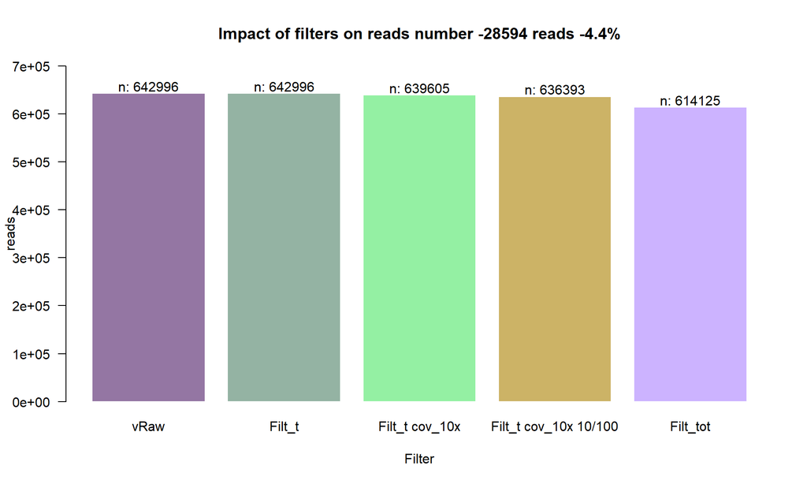

```r
Table_data <- read_excel(Table_data.file)
Table_data <- as.data.frame(Table_data)
rownames(Table_data) <- Table_data$Object
Table_data <- Table_data[,-c(1:3)]
Table_data <- as.data.frame(t(Table_data))
Table_data$Filter <- rownames(Table_data)

# Basic Barplot : reads number
my_bar <- barplot(Table_data$reads_number, border=F , names.arg=Table_data$Filter,
                  las=1 ,
                  col=c(rgb(0.3,0.1,0.4,0.6) , rgb(0.3,0.5,0.4,0.6) , rgb(0.3,0.9,0.4,0.6) ,  rgb(0.8,0.7,0.4), rgb(0.8,0.7,1)) ,
                  ylim=c(0,700000) ,
                  main="Impact of filters on reads number -28594 reads -4.4%",
                  ylab = "reads", xlab="Filter")

# Add the text
text(my_bar, Table_data$reads_number+15000 , paste("n: ", Table_data$reads_number, sep="") ,cex=1)
```

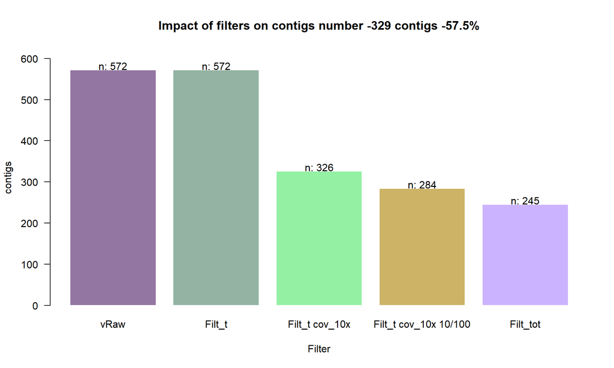

```r
# Basic Barplot : contigs
my_bar_contigs <- barplot(Table_data$contigs_number, border=F , names.arg=Table_data$Filter,
                          las=1 ,
                          col=c(rgb(0.3,0.1,0.4,0.6) , rgb(0.3,0.5,0.4,0.6) , rgb(0.3,0.9,0.4,0.6) ,  rgb(0.8,0.7,0.4), rgb(0.8,0.7,1)) ,
                          ylim=c(0,620) ,
                          main="Impact of filters on contigs number -329 contigs -57.5%",
                          ylab = "contigs", xlab="Filter")

# Add the text
text(my_bar_contigs, Table_data$contigs_number+10 , paste("n: ", Table_data$contigs_number, sep="") ,cex=1)
```

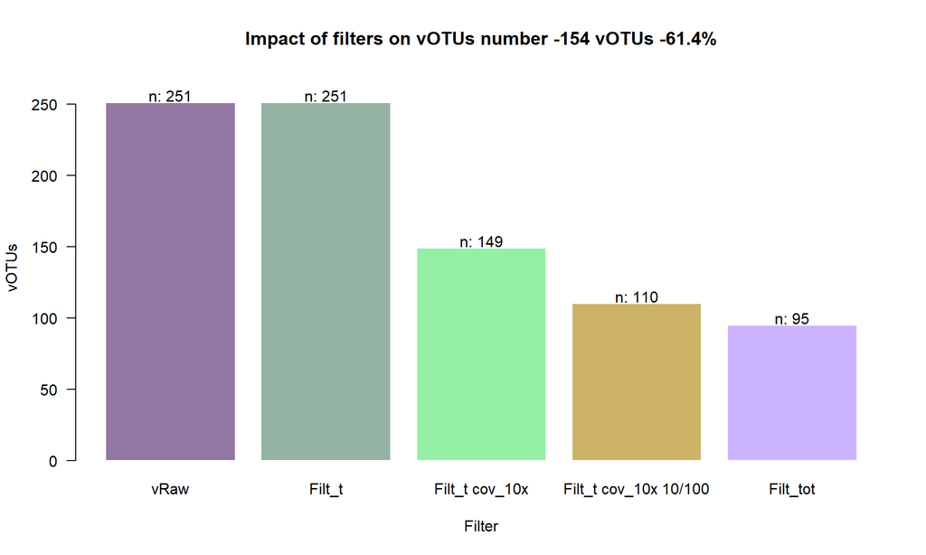

```r
# Basic Barplot : vOTUs
my_bar_otu <- barplot(Table_data$otu_number, border=F , names.arg=Table_data$Filter,
                      las=1 ,
                      col=c(rgb(0.3,0.1,0.4,0.6) , rgb(0.3,0.5,0.4,0.6) , rgb(0.3,0.9,0.4,0.6) ,  rgb(0.8,0.7,0.4), rgb(0.8,0.7,1)) ,
                      ylim=c(0,270) ,
                      main="Impact of filters on vOTUs number -154 vOTUs -61.4%",
                      ylab = "vOTUs", xlab="Filter" )

# Add the text
text(my_bar_otu, Table_data$otu_number+5 , paste("n: ", Table_data$otu_number, sep="") ,cex=1)
```

**En sortie du pipe on a 6 fichiers :**

1. `Stat_by seqid` = contigs et seqid pour chaque librairie et le nombre de reads
2. `seq_hits_info` = stat de chaque contig
3. `Tax_table` = taxonomie virale
4. `count_table` = nombre de reads/ librairie (faire le tableau présence/absence)
5. `OTU_stat` = stat pour chaque Magroupe
6. `Viral_contigs` = fichier fasta des reads des contigs

Il faut ajouter le fichier `Metadata`, (fichier qui regroupe toutes les infos de chaque librairie)

Il faut garder le `count_table` avant filtre (données brutes)

# 2- Analyses du séquençage

## 2-1 : Analyses des statistiques générales / statistiques descriptives

Design expérimental, nombre de librairies + les contrôles et undetermined pour les jeux de données les possédant (pas visible dans le jeux de données Sénégal présenté)

Analyse du run selon le tableau stats : exemple ci-dessous (*data Sénégal*)

```r
datatable(read_csv(Stats_run.file), editable = 'cell', filter = 'top')
```

|  | ...1 | All-sample | Sample_S-16-0139_4 | Sample_S-16-0138_6 | Sample_S-16-0143_3 | Sample_S-16-0142_5 | Sample_S-16-0144_1 | Sample_S-16-0145_0 | Sample_S-16-0146_8 | Sample_S-16-0147_6 | Sample_S-16-0148_4 | Sample_S-16-0149_2 | Sample_S-16-0141_7 | Sample_S-16-0140_9 |
| --- | --- | --- | --- | --- | --- | --- | --- | --- | --- | --- | --- | --- | --- | --- |
| 1 | Total read R1 | 910618757 | 75462674 | 81835491 | 60989480 | 68201528 | 84636141 | 77496606 | 80029146 | 104355164 | 74289367 | 75028883 | 67867165 | 60427112 |
| 2 | Total read R2 | 0 | 0 | 0 | 0 | 0 | 0 | 0 | 0 | 0 | 0 | 0 | 0 | 0 |
| 3 | Avg read length R1 | 150 | 150 | 150 | 150 | 150 | 150 | 150 | 150 | 150 | 150 | 150 | 150 | 150 |
| 4 | Avg read length R2 | 0 | 0 | 0 | 0 | 0 | 0 | 0 | 0 | 0 | 0 | 0 | 0 | 0 |
| 5 | Reads 1 cleaned | 897804445 | 74588355 | 80501166 | 60037698 | 67231575 | 83353869 | 76580661 | 78753596 | 102846356 | 73172463 | 73891843 | 67123806 | 59723057 |
| 6 | Reads 2 cleaned | 0 | 0 | 0 | 0 | 0 | 0 | 0 | 0 | 0 | 0 | 0 | 0 | 0 |
| 7 | Avg cleaned read length R1 (after cutadapt) | 144.22 | 145.5 | 142.94 | 143.82 | 144.02 | 143.27 | 145.45 | 143.46 | 143.94 | 143.42 | 143.51 | 145.92 | 145.4 |
| 8 | Avg cleaned read length R2 (after cutadapt) | 0 | 0 | 0 | 0 | 0 | 0 | 0 | 0 | 0 | 0 | 0 | 0 | 0 |
| 9 | Avg insert_size | 0 | 0 | 0 | 0 | 0 | 0 | 0 | 0 | 0 | 0 | 0 | 0 | 0 |
| 10 | Map on Diptera | 852805388 | 73329476 | 74326902 | 55964113 | 64942975 | 78964581 | 74045162 | 70037411 | 96064150 | 70317483 | 70142353 | 65857939 | 58812843 |

[output cut: 27 more lines]

## 2-2 : Vérification de l’homogénéité des données (voir s’il y a des biais de manip, si beaucoup de plaques d’extraction)

- Reads_totaux/echantillon
- Reads viraux/échantillon
- Reads en fonction des différentes variables
- Reads des contrôles et diversité virale ?
- Analyse de la distribution des reads : Est-ce que les données suivent une loi normale ? `Shapiro test`

```r
count_otu_Cx <- read_csv(Count_table.file)
apply(count_otu_Cx[,-1], 2, shapiro.test) #p-value > 0.05 indique que la distribution des données n’est pas significativement différente de la distribution normale. En d’autres termes, nous pouvons supposer la normalité des données (ce qui n'est pas le cas ici).
```

```
## $`Sample_S-16-0141_7`
##
##  Shapiro-Wilk normality test
##
## data:  newX[, i]
## W = 0.28161, p-value < 2.2e-16
##
##
## $`Sample_S-16-0148_4`
##
##  Shapiro-Wilk normality test
##
## data:  newX[, i]
## W = 0.35812, p-value < 2.2e-16
##
##
## $`Sample_S-16-0143_3`
##
##  Shapiro-Wilk normality test
##
## data:  newX[, i]
## W = 0.24563, p-value < 2.2e-16
##
##
## $`Sample_S-16-0144_1`
##
##  Shapiro-Wilk normality test
##
## data:  newX[, i]
## W = 0.42619, p-value < 2.2e-16
##
##
## $`Sample_S-16-0147_6`
##
##  Shapiro-Wilk normality test
##
## data:  newX[, i]
## W = 0.14888, p-value < 2.2e-16
##
##
```

[output cut: 39 more lines]

```
##
## $`Sample_S-16-0140_9`
##
##  Shapiro-Wilk normality test
##
## data:  newX[, i]
## W = 0.33753, p-value < 2.2e-16
##
##
## $`Sample_S-16-0138_6`
##
##  Shapiro-Wilk normality test
##
## data:  newX[, i]
## W = 0.16604, p-value < 2.2e-16
```

La distribution normale des données est basée sur la moyenne et la variance. Si **distribution Normale** = **TESTS PARAMETRIQUES**, sinon **TESTS NON PARAMETRIQUES** (Pour les tests non paramétriques il n’y a pas d’hypothèse sur la distribution des observations des échantillons, ils se basent sur des rangs d’observation)

Test Stat de `Kruskal-wallis` pour les données non paramétriques (avec n > 2).

## 2-3 : Analyse de la Taxonomie

**La taxonomie virale est basée selon la classification de l’ICTV**

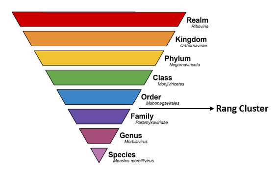

L’assignation taxonomique des contigs se fait par BLAST sur les bases de données de 2021 mais il faut faire une correction « manuelle » en corrigeant le `NA` des colonnes `Phylum`, `Order`, `Nucleic_acid`, `Host` selon [Shi et al.](https://www.nature.com/articles/nature20167), [Koonin et al.](https://www.sciencedirect.com/science/article/pii/S0042682215000859) et l’[ICTV](https://ictv.global/taxonomy).

Le rang `Cluster` est intermédiaire entre `Order` et `Family`.

### 2-3-2 : Nettoyage des NA du fichier TAX_Table : remettre dans l’ordre

- Harmoniser la dénomination de la colonne `Host`. On retrouve souvent `Culicidae`/`Diptera`/`Insecta`/`Insecta_other`/`other diptera`. En fonction du nom de l’espèce on peut modifier et mettre `Culicidae` ou `Arthropod_other` ou `insecta_other` (`NA` restant = Arthropodes dans le jeu de données Sénégal : exemple de manip à faire)

```r
taxo_table_Cx <- read_excel(Taxo_table.file)
taxo_table_Cx <- taxo_table_Cx[,-1]
taxo_table_Cx[is.na(taxo_table_Cx$hosts_taxon), "hosts_taxon"] <- "Arthropoda_other"
```

- Phylum `RNA` ou `DNA` corrigé par `cluster_phylum` s’il y a lieu

```r
taxo_table_Cx[unique(grep("RNA", taxo_table_Cx$phylum)), colnames(taxo_table_Cx) %in% "phylum"] <- "cluster_phylum"
taxo_table_Cx[unique(grep("DNA", taxo_table_Cx$phylum)), colnames(taxo_table_Cx) %in% "phylum"] <- "cluster_phylum"
```

- Order `NA` corrigé par `cluster_order` s’il y a lieu

```r
taxo_table_Cx[is.na(taxo_table_Cx$order), "order"] <- "cluster_order"
```

- Cluster `Permutotetra_unclass` => `Permutotetra`

```r
taxo_table_Cx[unique(grep("Permutotetra_unclass", taxo_table_Cx$cluster)), colnames(taxo_table_Cx) %in% "cluster"] <- "Permutotetra"
```

- Cluster `Luteo-Sobemo` => `Toli_unclass`

```r
taxo_table_Cx[unique(grep("Luteo-Sobemo", taxo_table_Cx$cluster)), colnames(taxo_table_Cx) %in% "cluster"] <- "Toli_unclass"
```

- Phylum `Luteo-Sobemo` => `Kitrinoviricota`

```r
taxo_table_Cx[unique(grep("Luteo-Sobemo", taxo_table_Cx$phylum)), colnames(taxo_table_Cx) %in% "phylum"] <- "Kitriniviricota"
```

- Order `Luteo-Sobemo` => `Tolivirales`

```r
taxo_table_Cx[unique(grep("Luteo-Sobemo", taxo_table_Cx$order)), colnames(taxo_table_Cx) %in% "order"] <- "Tolivirales"
```

Cette correction se fait par le `TaxID` en allant chercher les info sur le site du [NCBI](https://www.ncbi.nlm.nih.gov/). Si on ne trouve pas, regarder le blast des contigs et prendre la taxo de l’espèce la plus proche.

### 2-3-2 : Elimination des OTUs

- Dans la colonne `Host`, on peut éliminer `Bacteria`/`Fungi`/`Viridiplantae`/`Vertebrates`
- Dans la colonne `Order`, on peut éliminer les `Caudovirales` et les `Levivirales` car virus de phages

```r
count_otu_taxo_Cx <- merge(count_otu_Cx, taxo_table_Cx, by = "tax_id")
count_otu_taxo_Cx <- count_otu_taxo_Cx %>%
  subset(Nucleic_acid != "ssRNA-RT") %>%
  subset(hosts_taxon != "Fungi") %>%
  subset(hosts_taxon != "Vertebrate") %>%
  subset(hosts_taxon != "Viridiplantae") %>%
  subset(hosts_taxon != "Bacteria") %>%
  subset(order != "Caudovirales") %>%
  subset(order != "Levivirales")
```

### 2-3-3 : Elimination des librairies outlayers

- Selon les questions de recherche on peut éliminer les OTUs qui sont dans moins de **5 librairies** (si plus de 100 librairies) -> pas besoin pour le Sénégal
- Elimination des librairies qui n’ont **aucun reads viraux**

```r
# Changer noms des échantillons
count_otu_taxo_Cx <- rename.vars(count_otu_taxo_Cx, from = c("Sample_S-16-0138_6","Sample_S-16-0139_4","Sample_S-16-0140_9","Sample_S-16-0141_7","Sample_S-16-0142_5","Sample_S-16-0143_3","Sample_S-16-0144_1","Sample_S-16-0145_0","Sample_S-16-0146_8","Sample_S-16-0147_6","Sample_S-16-0148_4","Sample_S-16-0149_2"), to = c("PF4","PF5","TF4","TF5","PD4","PD5","TD4","TD5","PK4","PK5","TK4","TK5"))
# name :  P = C.Poicilipes, T = C.tritaeniorhynchus, F = Ferlo - Ponds, D = Diama - Delta, K = KMS - Lake, 4 = 2014, 5 = 2015

# Elimination librairies sans reads viraux
count_otu_taxo_Cx$sum_reads <- rowSums(count_otu_taxo_Cx[,colnames(count_otu_taxo_Cx) %in% c("PF4","PF5","TF4","TF5","PD4","PD5","TD4","TD5","PK4","PK5","TK4","TK5")])
count_otu_taxo_Cx <- count_otu_taxo_Cx %>%
  subset(sum_reads > 0)
```

- L’analyse des reads viraux en fonction du nombre d’OTU (fichier OTU présence/absence et faire la somme totale) par échantillons permet de fixer un seuil et d’éliminer les **librairies outlayers** quand assez de librairies. Analyser les **contrôles** (si présence de contrôles)

```r
rownames(count_otu_taxo_Cx) <- count_otu_taxo_Cx$species
abund_OTU_transvers_Cx <- as.data.frame(t(count_otu_taxo_Cx[,colnames(count_otu_taxo_Cx) %in% c("PF4","PF5","TF4","TF5","PD4","PD5","TD4","TD5","PK4","PK5","TK4","TK5")]))
abund_OTU_transvers_Cx$spe_richness <- vegan::specnumber(abund_OTU_transvers_Cx)
abund_OTU_transvers_Cx$nbr_reads <- colSums(count_otu_taxo_Cx[,colnames(count_otu_taxo_Cx) %in% c("PF4","PF5","TF4","TF5","PD4","PD5","TD4","TD5","PK4","PK5","TK4","TK5")])

cor.test(abund_OTU_transvers_Cx$nbr_reads,abund_OTU_transvers_Cx$spe_richness, method="pearson", alternative="two.sided")
```

```
##
##  Pearson's product-moment correlation
##
## data:  abund_OTU_transvers_Cx$nbr_reads and abund_OTU_transvers_Cx$spe_richness
## t = 5.7114, df = 10, p-value = 0.0001952
## alternative hypothesis: true correlation is not equal to 0
## 95 percent confidence interval:
##  0.6044174 0.9644993
## sample estimates:
##       cor
## 0.8748533
```

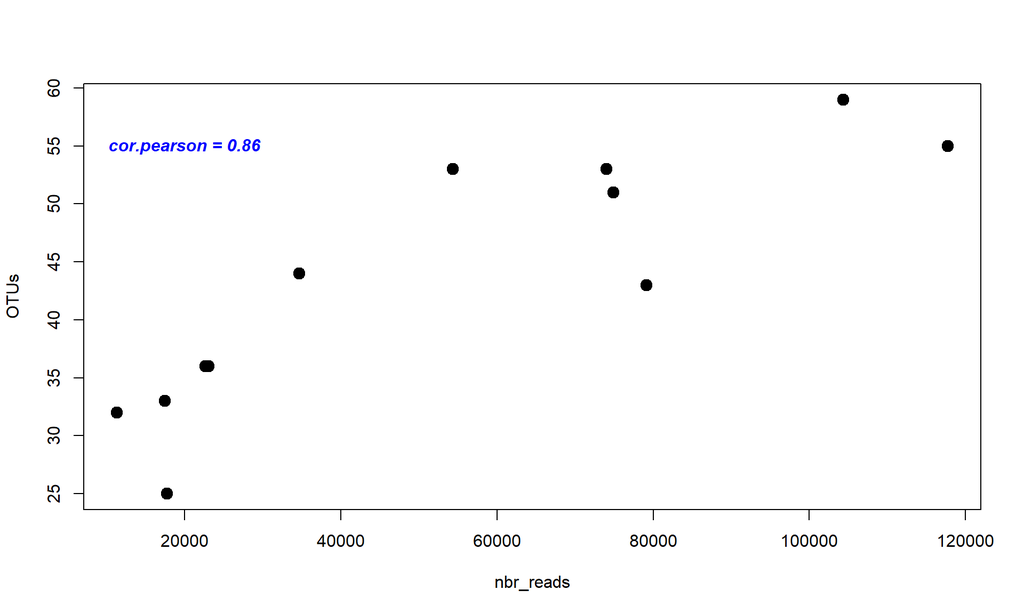

```r
plot(abund_OTU_transvers_Cx$nbr_reads,abund_OTU_transvers_Cx$spe_richness, xlab = "nbr_reads", ylab= "OTUs",  cex = 1.5, pch = 19)
text(20000,55,"cor.pearson = 0.86", font = 4, col = "blue")
```

- L’analyse des reads viraux en fonction du nombre de moustiques présents dans chaque librairies

```r
abund_OTU_transvers_Cx$Sample <- rownames(abund_OTU_transvers_Cx)
abund_OTU_transvers_Cx <- abund_OTU_transvers_Cx[sort(abund_OTU_transvers_Cx$Sample),]

# Mosquito number
abund_OTU_transvers_Cx$nbr_mos <- c(94, 551, 112, 103, 786, 383, 3829,3921, 98, 85, 4062, 3185)

# Species
abund_OTU_transvers_Cx$Host <- rep(c("C. poicilipes", "C. tritaeniorhynchus"), each=6, times=1)

# Sites
abund_OTU_transvers_Cx$Site <- rep(c("Diama", "Ferlo","KMS"), times = 2, each = 2)

# Year
abund_OTU_transvers_Cx$Year <- rep(c("2014", "2015"), each=1, times=6)

cor.test(abund_OTU_transvers_Cx$nbr_mos,abund_OTU_transvers_Cx$nbr_reads, method="pearson", alternative="two.sided")
```

```
##
##  Pearson's product-moment correlation
##
## data:  abund_OTU_transvers_Cx$nbr_mos and abund_OTU_transvers_Cx$nbr_reads
## t = 0.30237, df = 10, p-value = 0.7686
## alternative hypothesis: true correlation is not equal to 0
## 95 percent confidence interval:
##  -0.5063796  0.6344288
## sample estimates:
##       cor
## 0.0951835
```

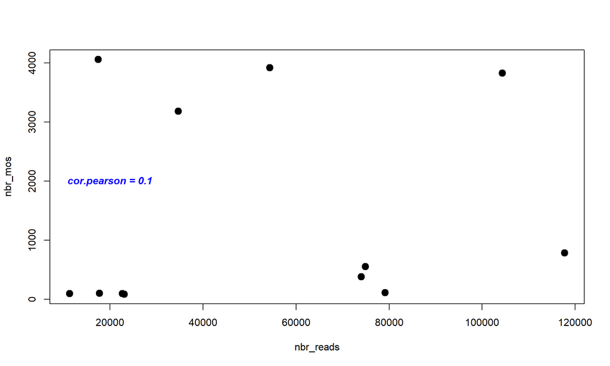

```r
plot(abund_OTU_transvers_Cx$nbr_reads,abund_OTU_transvers_Cx$nbr_mos, xlab = "nbr_reads", ylab= "nbr_mos", cex = 1.5, pch = 19)
text(20000,2000,"cor.pearson = 0.1", font = 4, col = "blue")
```

- Analyse de la composition générale (Nb de phylum/ Nb de Cluster/ Nb d’OTU)

```r
# cluster
unique(count_otu_taxo_Cx$cluster)
```

```
##  [1] "Reo"              "Rhabdo"           "Birna"            "Nege"
##  [5] "Mesoni"           "Solemo"           "Phasma"           "Chu"
##  [9] "Narna"            "Chryso"           "Toli_unclass"     "Noda"
## [13] "Partiti"          "Permutotetra"     "Dicistro"         "Kelp_fly_cluster"
## [17] "Luteo"            "Tombus"           "Virga"            "Phenui"
## [21] "Ifla"             "Polycipi"         "Picorna_unclass"  "Mononega_unclass"
## [25] "Xinmo"            "Toti"
```

```r
table(count_otu_taxo_Cx$cluster)
```

```
##
##            Birna           Chryso              Chu         Dicistro
##                2                4                2                6
##             Ifla Kelp_fly_cluster            Luteo           Mesoni
##                4                1                4                2
## Mononega_unclass            Narna             Nege             Noda
##                1                3                6                7
##          Partiti     Permutotetra           Phasma           Phenui
##                7                3                1                5
##  Picorna_unclass         Polycipi              Reo           Rhabdo
##                1                2                8                9
##           Solemo     Toli_unclass           Tombus             Toti
##                6                1                3                5
##            Virga            Xinmo
##                5                1
```

```r
# order
unique(count_otu_taxo_Cx$order)
```

```
##  [1] "Reovirales"         "Mononegavirales"    "Birna_order"
##  [4] "Martellivirales"    "Nidovirales"        "Sobelivirales"
##  [7] "Bunyavirales"       "Jingchuvirales"     "Wolframvirales"
## [10] "Ghabrivirales"      "Tolivirales"        "Nodamuvirales"
## [13] "Durnavirales"       "Permutotetra_order" "Picornavirales"
```

```r
table(count_otu_taxo_Cx$order)
```

```
##
##        Birna_order       Bunyavirales       Durnavirales      Ghabrivirales
##                  2                  6                  7                  9
##     Jingchuvirales    Martellivirales    Mononegavirales        Nidovirales
##                  2                 11                 11                  2
##      Nodamuvirales Permutotetra_order     Picornavirales         Reovirales
##                  7                  3                 14                  8
##      Sobelivirales        Tolivirales     Wolframvirales
##                  6                  8                  3
```

```r
# Phylum
unique(count_otu_taxo_Cx$phylum)
```

```
## [1] "Duplornaviricota" "Negarnaviricota"  "Incertae sedis"   "Kitrinoviricota"
## [5] "Pisuviricota"     "Lenarviricota"
```

```r
table(count_otu_taxo_Cx$phylum)
```

```
##
## Duplornaviricota   Incertae sedis  Kitrinoviricota    Lenarviricota
##               17                6               25                3
##  Negarnaviricota     Pisuviricota
##               19               29
```

*PS : Si travail sur clusters faire ces manips là :*

```r
# Pour obtenir une table de comptage pour les clusters
count_cluster_Cx <- aggregate( . ~ cluster, data = count_otu_taxo_Cx[,colnames(count_otu_taxo_Cx) %in% c("PF4","PF5","TF4","TF5","PD4","PD5","TD4","TD5","PK4","PK5","TK4","TK5", "cluster")], function(x) x=sum(x))
rownames(count_cluster_Cx) <- count_cluster_Cx$cluster
count_cluster_Cx$sum_reads <- apply(count_cluster_Cx[,!colnames(count_cluster_Cx) %in% ("cluster")], 1, sum)
datatable(count_cluster_Cx, editable = 'cell', filter = 'top')
```

|  | cluster | TF5 | TK4 | PD5 | TD4 | PK5 | TK5 | PF5 | PD4 | PK4 | TD5 | TF4 | PF4 | sum_reads |
| --- | --- | --- | --- | --- | --- | --- | --- | --- | --- | --- | --- | --- | --- | --- |
| Birna | Birna | 0 | 908 | 175 | 10201 | 0 | 22 | 0 | 18 | 43 | 7086 | 0 | 0 | 18453 |
| Chryso | Chryso | 760 | 15 | 39 | 2992 | 59 | 38 | 0 | 0 | 0 | 1086 | 494 | 0 | 5483 |
| Chu | Chu | 7394 | 0 | 0 | 7429 | 0 | 0 | 0 | 0 | 0 | 2060 | 0 | 0 | 16883 |
| Dicistro | Dicistro | 0 | 347 | 15526 | 815 | 1597 | 1565 | 0 | 279 | 456 | 1507 | 0 | 0 | 22092 |
| Ifla | Ifla | 443 | 567 | 714 | 2317 | 3742 | 978 | 1017 | 3050 | 1623 | 908 | 398 | 2273 | 18030 |
| Kelp_fly_cluster | Kelp_fly_cluster | 0 | 0 | 0 | 0 | 0 | 0 | 0 | 0 | 0 | 0 | 0 | 214 | 214 |
| Luteo | Luteo | 1207 | 4351 | 1963 | 4534 | 4017 | 4141 | 34 | 13 | 1245 | 3109 | 2220 | 2290 | 29124 |
| Mesoni | Mesoni | 19 | 60 | 142 | 9327 | 40598 | 4332 | 41 | 14223 | 42395 | 3843 | 829 | 42534 | 158343 |
| Mononega_unclass | Mononega_unclass | 385 | 0 | 134 | 3822 | 0 | 20 | 0 | 0 | 0 | 1573 | 127 | 0 | 6061 |
| Narna | Narna | 219 | 43 | 116 | 126 | 692 | 27 | 30 | 25 | 283 | 120 | 165 | 1578 | 3424 |

[output cut: 16 more lines]

*Pour le reste on est sur le même script/les mêmes manips*

## 2.4 : Analyse des communautés virales (utilisation du package Phyloseq possible si préférences)

*Package Phyloseq pas détaillé ici (hormis partie courbe de raréfaction) car peu utilisé, redite avec le reste et long, si besoin d’informations sur phyloseq suivre ces pages internets :*

https://micca.readthedocs.io/en/latest/phyloseq.html

https://vaulot.github.io/tutorials/Phyloseq_tutorial.html

https://web.stanford.edu/class/bios221/labs/phyloseq/lab_phyloseq.html

*Packages* `Vegan`/`ade4`/`tibble`/`phyloseq`/`ggplot2`

```r
library("tibble")
library("phyloseq")
library("ggplot2")
library("ade4")
library("vegan")
```

**3 Fichiers** sont nécessaires :

- `OTU_table`
- `Tax_table`
- `Sample_data` (metadata)

```r
# Renommer les librairies selon les index des samples
otu_mat_Cx <- as.tibble(count_otu_taxo_Cx[,1:13]) %>%
  tibble::column_to_rownames("tax_id")

tax_mat_Cx <- taxo_table_Cx[,c(1,4:12)] %>%
  tibble::column_to_rownames("tax_id")

samples_df_Cx <- read_excel(Metadata.file, sheet = "Feuil1")

# Fusionner les deux tables
samples_df_Cx <- samples_df_Cx[17:28,] %>%
  tibble::column_to_rownames("sample")

samples_df_Cx <- rename.vars(samples_df_Cx, from = "species", to = "Host")
```

```
##
## Changing in samples_df_Cx
## From: species
## To:   Host
```

```r
otu_mat_Cx <- as.matrix(otu_mat_Cx)
tax_mat_Cx <- as.matrix(tax_mat_Cx)

OTU_Cx = otu_table(otu_mat_Cx, taxa_are_rows = TRUE)
TAX_Cx = tax_table(tax_mat_Cx)
samples_Cx = sample_data(samples_df_Cx)

carbom_Cx <- phyloseq(OTU_Cx, TAX_Cx, samples_Cx)
carbom_Cx
```

```
## phyloseq-class experiment-level object
## otu_table()   OTU Table:         [ 99 taxa and 12 samples ]
## sample_data() Sample Data:       [ 12 samples by 10 sample variables ]
## tax_table()   Taxonomy Table:    [ 99 taxa by 9 taxonomic ranks ]
```

**Le nombre d’échantillons et d’OTU doit être le même dans tous les fichiers**

### 2.4.1 : Courbe de raréfaction

L’analyse des **courbes de raréfaction** nous permet de savoir si notre profondeur de séquençage est suffisante pour capter les organismes en faible proportion et ainsi savoir si notre richesse estimée correspond à la richesse réelle du virome. Elle permet d’éliminer les **librairies « outlayers »** qui resteraient après les premières manip de filtration

*Principe* : On Compte le nombre d’OTU pour un ensemble de sous-échantillon à différents intervalles de profondeur. On regarde en Y le nb d’OTU observées et en X le nb de lecture. L’obtention d’un **plateau** permet de dire si l’échantillon a une profondeur de séquençage optimale.

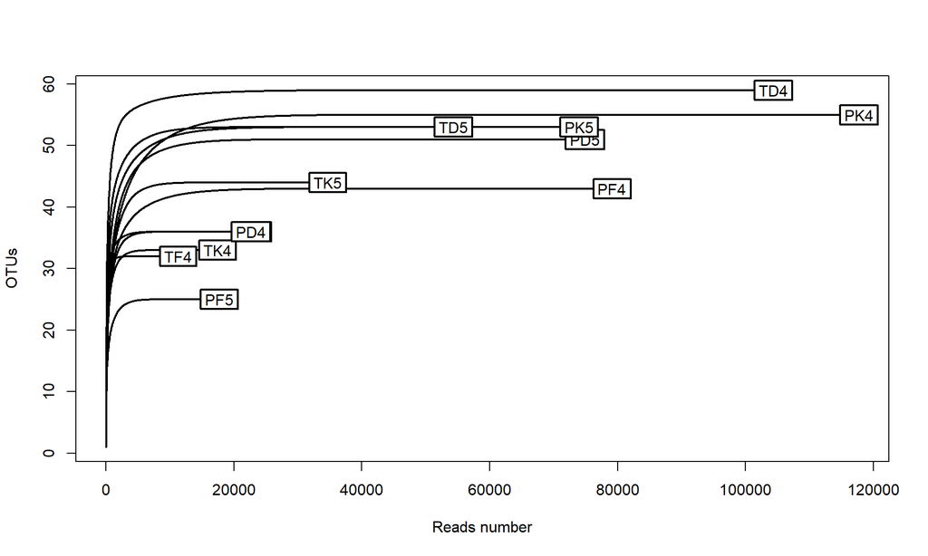

```r
rarecurve(t(otu_table(carbom_Cx)), step=50, cex=1, lwd = 2, ylab = "OTUs", xlab = "Reads number") # avant normalisation
```

### 2.4.2 : Exploration de la biodiversité par visualisation de la composition

- Barplot composition (OTU ou Cluster abondance /sample) + statistiques : possibilité de le faire avec `phyloseq`

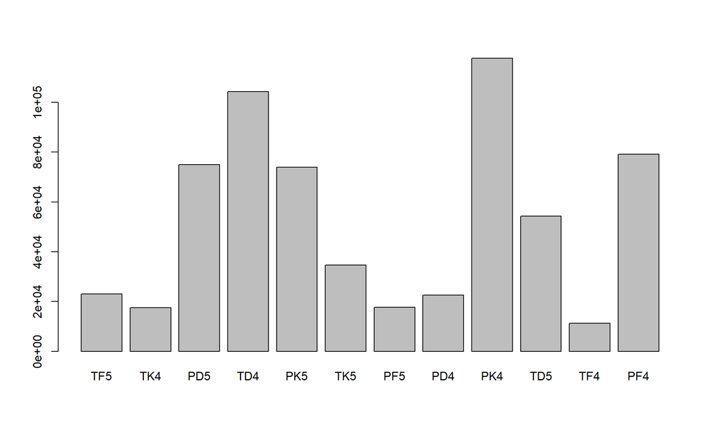

```r
barplot(colSums(count_otu_taxo_Cx[,colnames(count_otu_taxo_Cx) %in% c("PF4","PF5","TF4","TF5","PD4","PD5","TD4","TD5","PK4","PK5","TK4","TK5")]))
```

```r
wilcox_table <- as.data.frame(t(count_otu_taxo_Cx[,colnames(count_otu_taxo_Cx) %in% c("PF4","PF5","TF4","TF5","PD4","PD5","TD4","TD5","PK4","PK5","TK4","TK5")]))
wilcox_table$total <- apply(wilcox_table, 1, sum)
wilcox_table$sample <- rownames(wilcox_table)
wilcox_table <- as.data.frame(wilcox_table[,colnames(wilcox_table) %in% c("total", "sample")])

wsrTest(wilcox_table$total)
```

```
##
##  Exact Wilcoxon Signed-Rank Test (with Pratt modification if zeros)
##
## data:  single sample=wilcox_table$total
## p-value = 0.0004883
## alternative hypothesis: true median is not equal to 0
## 95 percent confidence interval:
##  22820 76570
## sample estimates:
## median (Hodges-Lehmann estimator)
##                          48930.53
```

Pour `OTU_table` : les données doivent être normalisées **(après les analyses préliminaires)** pour être en abondance relative, soit (read OTU de l’échantillon/ read totaux de l’échantillon) x 10 000

```r
count_otu_taxo_Cx[,colnames(count_otu_taxo_Cx) %in% c("PF4","PF5","TF4","TF5","PD4","PD5","TD4","TD5","PK4","PK5","TK4","TK5")] <- lapply(count_otu_taxo_Cx[,colnames(count_otu_taxo_Cx) %in% c("PF4","PF5","TF4","TF5","PD4","PD5","TD4","TD5","PK4","PK5","TK4","TK5")], function(x) round(1e4*x/sum(x, na.rm=TRUE), digits = 0))
lapply(count_otu_taxo_Cx[,colnames(count_otu_taxo_Cx) %in% c("PF4","PF5","TF4","TF5","PD4","PD5","TD4","TD5","PK4","PK5","TK4","TK5")], sum) # check normalisation
```

```
## $TF5
## [1] 9999
##
## $TK4
## [1] 10002
##
## $PD5
## [1] 9999
##
## $TD4
## [1] 10000
##
## $PK5
## [1] 9997
##
## $TK5
## [1] 10000
##
## $PF5
## [1] 10001
##
## $PD4
## [1] 10004
##
## $PK4
## [1] 9998
##
## $TD5
## [1] 10000
##
## $TF4
## [1] 9998
##
## $PF4
## [1] 10001
```

```r
summary(count_otu_taxo_Cx)
```

```
##      tax_id             TF5            TK4            PD5
##  Min.   :  37368   Min.   :   0   Min.   :   0   Min.   :   0
##  1st Qu.:1922927   1st Qu.:   0   1st Qu.:   0   1st Qu.:   0
##  Median :2170576   Median :   0   Median :   0   Median :   1
##  Mean   :2143631   Mean   : 101   Mean   : 101   Mean   : 101
##  3rd Qu.:2687686   3rd Qu.:  42   3rd Qu.:  11   3rd Qu.:  12
##  Max.   :2819084   Max.   :3136   Max.   :1629   Max.   :2979
##       TD4              PK5            TK5            PF5            PD4
##  Min.   :   0.0   Min.   :   0   Min.   :   0   Min.   :   0   Min.   :   0.0
##  1st Qu.:   0.0   1st Qu.:   0   1st Qu.:   0   1st Qu.:   0   1st Qu.:   0.0
##  Median :  10.0   Median :   2   Median :   0   Median :   0   Median :   0.0
##  Mean   : 101.0   Mean   : 101   Mean   : 101   Mean   : 101   Mean   : 101.1
##  3rd Qu.:  75.5   3rd Qu.:  27   3rd Qu.:   8   3rd Qu.:   3   3rd Qu.:  11.0
##  Max.   :1868.0   Max.   :5472   Max.   :3412   Max.   :2508   Max.   :4517.0
##       PK4              TD5            TF4            PF4
##  Min.   :   0.0   Min.   :   0   Min.   :   0   Min.   :   0.0
##  1st Qu.:   0.0   1st Qu.:   0   1st Qu.:   0   1st Qu.:   0.0
##  Median :   1.0   Median :   3   Median :   0   Median :   0.0
##  Mean   : 101.0   Mean   : 101   Mean   : 101   Mean   : 101.0
##  3rd Qu.:  10.5   3rd Qu.:  47   3rd Qu.:  33   3rd Qu.:  13.5
##  Max.   :3438.0   Max.   :2111   Max.   :2431   Max.   :5118.0
##  Nucleic_acid          genome            cluster             clade
##  Length:99          Length:99          Length:99          Length:99
##  Class :character   Class :character   Class :character   Class :character
##  Mode  :character   Mode  :character   Mode  :character   Mode  :character
##
##
##
##    kingdom             phylum             class              order
##  Length:99          Length:99          Length:99          Length:99
##  Class :character   Class :character   Class :character   Class :character
##  Mode  :character   Mode  :character   Mode  :character   Mode  :character
##
##
##
##     family             genus             species            no.rank
##  Length:99          Length:99          Length:99          Length:99
##  Class :character   Class :character   Class :character   Class :character
##  Mode  :character   Mode  :character   Mode  :character   Mode  :character
##
```

[output cut: 22 more lines]

```
##
##  hosts_family       hosts_subfamily    hosts_genus        hosts_species
##  Length:99          Length:99          Length:99          Length:99
##  Class :character   Class :character   Class :character   Class :character
##  Mode  :character   Mode  :character   Mode  :character   Mode  :character
##
##
##
##    sum_reads
##  Min.   :   104.0
##  1st Qu.:   367.5
##  Median :  1149.0
##  Mean   :  6376.8
##  3rd Qu.:  6707.0
##  Max.   :145572.0
```

- Heatmap (présence/absence) : nécessite transformation des données :

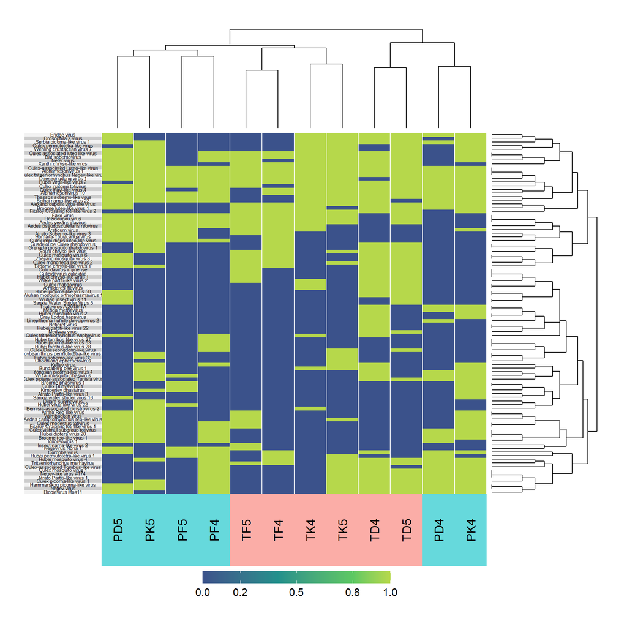

```r
decostand(count_otu_taxo_Cx[,colnames(count_otu_taxo_Cx) %in% c("PF4","PF5","TF4","TF5","PD4","PD5","TD4","TD5","PK4","PK5","TK4","TK5")], method = "pa") %>%
superheat(# dendrograms
          row.dendrogram = T,
          col.dendrogram = T,
          # grid lines
          grid.hline.col = "white",
          grid.vline.col = "white",
          # bottom labels
          bottom.label.col = adjustcolor(c("#F8766D","#F8766D","#00BFC4","#F8766D","#00BFC4","#F8766D","#00BFC4","#00BFC4","#00BFC4","#F8766D","#F8766D","#00BFC4"), alpha.f = 0.6),
          bottom.label.text.angle = 90,
          bottom.label.text.size = 5,
          # left labels
          left.label.text.size = 2)
```

- Diagramme de Venn représentant le nombre et les proportions d’OTUs Partagés entre différentes conditions (OTUs “*généralistes*”)

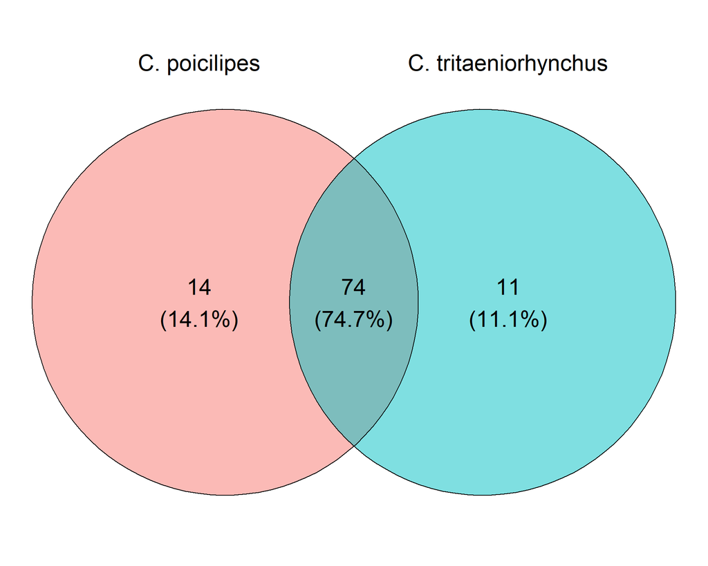

```r
## per species
spec.pa <- decostand(abund_OTU_transvers_Cx[,!colnames(abund_OTU_transvers_Cx) %in% c("spe_richness", "nbr_reads","Sample","nbr_mos", "Host", "Site", "Year")], method = "pa")
spec.pa <- as.data.frame(t(spec.pa))

spec.pa$poicilipes <- apply(spec.pa[,colnames(spec.pa) %in% c("PD4", "PD5", "PF4", "PF5", "PK4", "PK5")], 1, sum) # sum de toutes les colonnes appartenant à poicilipes pour chaque ligne
spec.pa$tritaeniorhynchus <- apply(spec.pa[,c("TD4", "TD5", "TF4", "TF5", "TK4", "TK5")], 1, sum) # sum de toutes les colonnes appartenant à tritaeniorhynchus pour chaque ligne

spec.pa$OTU <- rownames(spec.pa)

# Poicilipes
spec.pa_poi_pivot <- spec.pa %>%
  pivot_longer(
    cols = starts_with("P"), names_to = "Sample", values_to = "pres",
    values_drop_na = TRUE)

spec.pa_poi_pivot <- subset(spec.pa_poi_pivot,spec.pa_poi_pivot$pres == 1)

# Tritaeniorhynchus
spec.pa_tri_pivot <- spec.pa %>%
  pivot_longer(
    cols = starts_with("T"), names_to = "Sample", values_to = "pres",
    values_drop_na = TRUE)

spec.pa_tri_pivot <- subset(spec.pa_tri_pivot,spec.pa_tri_pivot$pres == 1)

spec.pa_pivot <- list( "C. poicilipes" = spec.pa_poi_pivot$OTU,
                       "C. tritaeniorhynchus" = spec.pa_tri_pivot$OTU)

## per sites
spec.pa$Diama <- apply(spec.pa[,colnames(spec.pa) %in% c("PD4", "PD5", "TD4", "TD5")], 1, sum) # sum de toutes les colonnes appartenant à Diama pour chaque ligne
spec.pa$Ferlo <- apply(spec.pa[,colnames(spec.pa) %in% c("PF4", "PF5", "TF4", "TF5")], 1, sum) # sum de toutes les colonnes appartenant à Ferlo pour chaque ligne
spec.pa$KMS <- apply(spec.pa[,colnames(spec.pa) %in% c("PK4", "PK5", "TK4", "TK5")], 1, sum) # sum de toutes les colonnes appartenant à KMS pour chaque ligne

# Diama
spec.pa_Diama_pivot <- spec.pa %>%
  pivot_longer(
    cols = contains("D"), names_to = "Sample", values_to = "pres",
    values_drop_na = TRUE)

spec.pa_Diama_pivot <- subset(spec.pa_Diama_pivot,spec.pa_Diama_pivot$pres == 1)

# Ferlo
spec.pa_Ferlo_pivot <- spec.pa %>%
  pivot_longer(
    cols = contains("F"), names_to = "Sample", values_to = "pres",
    values_drop_na = TRUE)

spec.pa_Ferlo_pivot <- subset(spec.pa_Ferlo_pivot,spec.pa_Ferlo_pivot$pres == 1)

# KMS
spec.pa_KMS_pivot <- spec.pa %>%
  pivot_longer(
    cols = contains("K"), names_to = "Sample", values_to = "pres",
    values_drop_na = TRUE)

spec.pa_KMS_pivot <- subset(spec.pa_KMS_pivot,spec.pa_KMS_pivot$pres == 1)


spec.pa_pivot_habitat <- list( Diama = spec.pa_Diama_pivot$OTU,
                               Ferlo = spec.pa_Ferlo_pivot$OTU,
                               KMS = spec.pa_KMS_pivot$OTU)

## per year

spec.pa$annee14<- apply(spec.pa[,colnames(spec.pa) %in% c("PD4", "PF4", "PK4", "TD4", "TF4", "TK4")], 1, sum) # sum de toutes les colonnes appartenant à poicilipes pour chaque ligne
spec.pa$annee15 <- apply(spec.pa[,colnames(spec.pa) %in% c("PD5", "PF5", "PK5", "TD5", "TF5", "TK5")], 1, sum) # sum de toutes les colonnes appartenant à tritaenirhynchus pour chaque ligne

# 2014
spec.pa_2014_pivot <- spec.pa %>%
  pivot_longer(
    cols = ends_with("4"), names_to = "Sample", values_to = "pres",
    values_drop_na = TRUE)

spec.pa_2014_pivot <- subset(spec.pa_2014_pivot,spec.pa_2014_pivot$pres == 1)

# 2015
spec.pa_2015_pivot <- spec.pa %>%
  pivot_longer(
    cols = ends_with("5"), names_to = "Sample", values_to = "pres",
    values_drop_na = TRUE)

spec.pa_2015_pivot <- subset(spec.pa_2015_pivot,spec.pa_2015_pivot$pres == 1)

spec.pa_pivot_annee <- list( "2014" = spec.pa_2014_pivot$OTU,
                             "2015" = spec.pa_2015_pivot$OTU)

# Graph GGvenn
# per species
ggvenn(
  spec.pa_pivot,
  fill_color = c("#F8766D", "#00BFC4", "#868686FF", "#CD534CFF"),
  stroke_size = 0.5, set_name_size = 8, text_size = 8
)
```

```r
# per sites
ggvenn(
  spec.pa_pivot_habitat,
  fill_color = c("#868686FF", "#868686FF", "#868686FF", "#CD534CFF"), fill_alpha = 0.4,
  stroke_size = 0.5, set_name_size = 8, text_size = 6
)
```

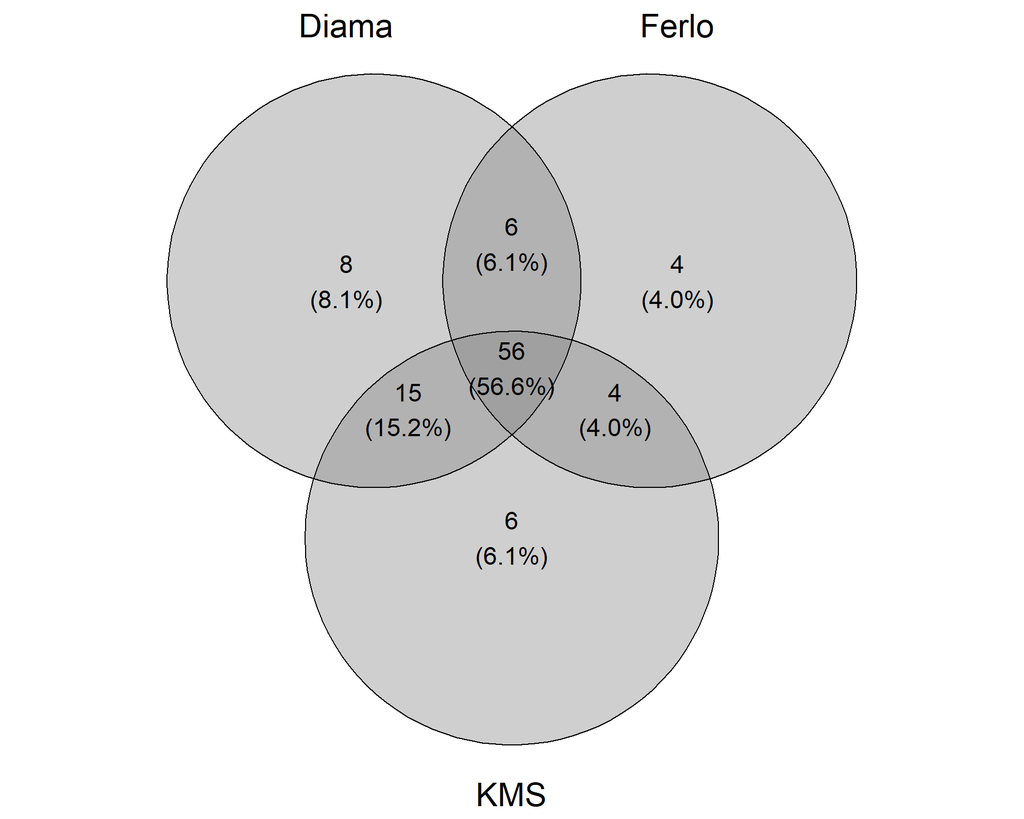

```r
# per year
ggvenn(
  spec.pa_pivot_annee,
  fill_color = c("#868686FF", "#868686FF", "#868686FF", "#CD534CFF"), fill_alpha = 0.4,
  stroke_size = 0.5, set_name_size = 8, text_size = 8
)
```

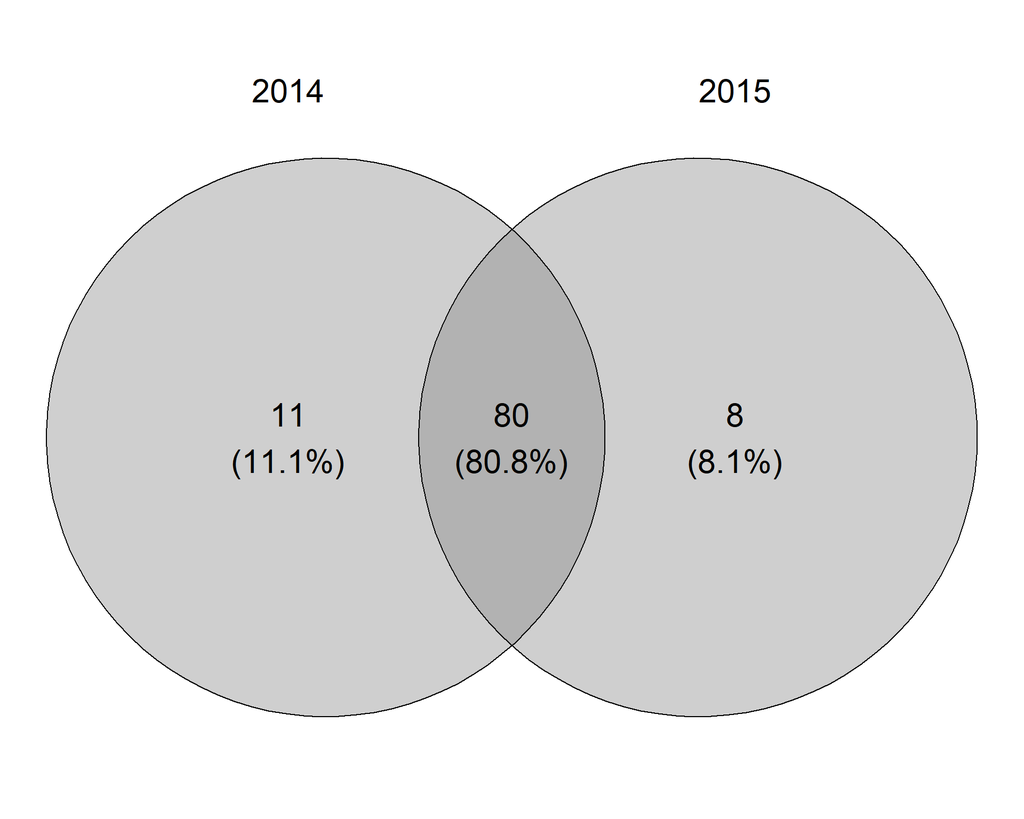

- Camembert pour représenter la diversité taxonomique de nos vOTUs

*Pour configurer/changer les couleurs ou l’ordre des parts de camembert, demander à Côme*

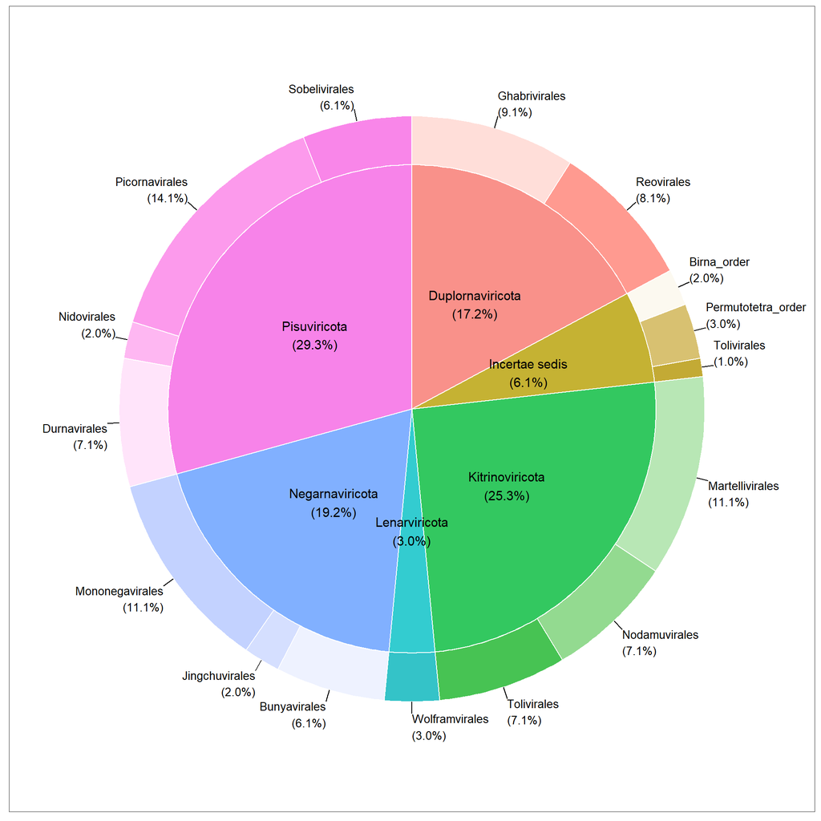

```r
PieDonut(count_otu_taxo_Cx, aes(pies=phylum, donuts=order), r0=0, showPieName=FALSE, showRatioThreshold = getOption("PieDonut.showRatioThreshold", 0.01), labelposition = getOption("PieDonut.labelposition", 1), donutLabelSize =3.5, pieLabelSize = 4, ratioByGroup=F)
```

### 2.4.3 : Exploration de l’ Alpha diversité avec des indices statistiques

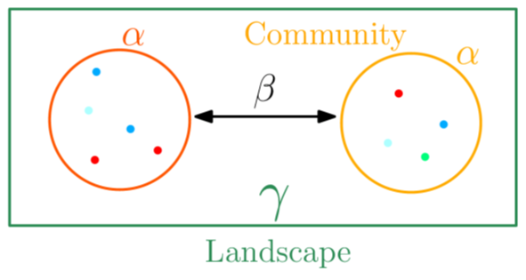

Figure : Représentation schématique de la diversité alpha et beta

**Diversité Alpha (intra communauté)**

- **Richesse Observée** (nombre d’espèces)

```r
abund_OTU_transvers_Cx$spe_richness <- abund_OTU_transvers_Cx %>%
  select(! c("spe_richness", "nbr_reads","Sample","nbr_mos", "Host", "Site", "Year")) %>%
  vegan::specnumber()
```

- **Indice de Shannon** (abondance de la distribution des espèces)

*Plus l’indice de Shanon est élevé plus la diversité est grande*

```r
abund_OTU_transvers_Cx$shannon <- abund_OTU_transvers_Cx %>%
  select(! c("spe_richness", "nbr_reads","Sample","nbr_mos", "Host", "Site", "Year")) %>%
  vegan::diversity(index="shannon")
```

- **Indice de Simpson** (probabilité que 2 OTU prises aléatoirement proviennent de la même espèce)

```r
abund_OTU_transvers_Cx$simpson <- abund_OTU_transvers_Cx %>%
  select(! c("spe_richness", "nbr_reads","Sample","nbr_mos", "Host", "Site", "Year", "shannon")) %>%
  vegan::diversity(index = "simpson")
```

*Exemple : boxplots*

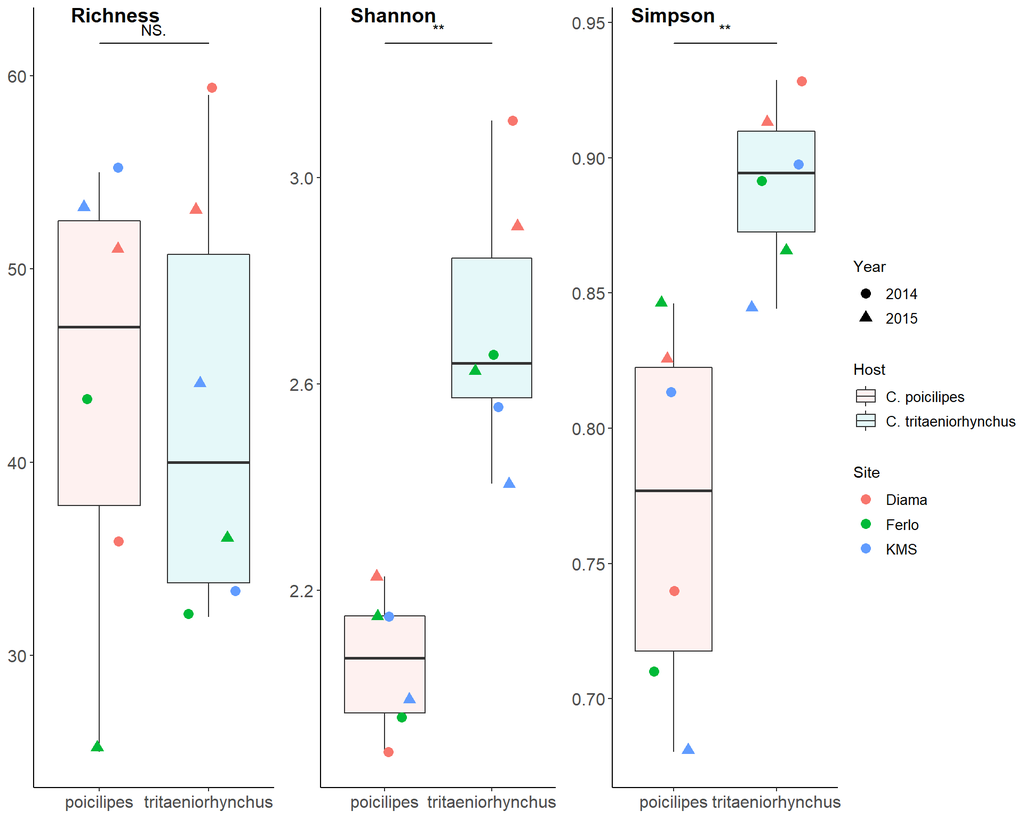

```r
shannon_Cx <- ggplot(abund_OTU_transvers_Cx, aes(x=Host, y=shannon)) +
  theme(axis.text.x = element_text(angle=90)) +
  geom_boxplot(aes(fill=Host), alpha=0.1) +
  theme_ipsum() +
  theme_classic() +
  geom_jitter(aes(shape = Year, col = Site), size=3, alpha=1, width = 0.25) +
  scale_x_discrete(labels=c("C. poicilipes" = "poicilipes", "C. tritaeniorhynchus" = "tritaeniorhynchus")) +
  geom_signif(comparisons = list(c("C. poicilipes", "C. tritaeniorhynchus")), test = "wilcox.test", map_signif_level=TRUE, tip_length = 0, col="black", y_position = 3.2) +
  labs(y=NULL, x=NULL) + theme(axis.text = element_text(size = 12)) + theme(legend.text = element_text(size = 10))

simpson_Cx <- ggplot(abund_OTU_transvers_Cx, aes(x=Host, y=simpson)) +
  theme(axis.text.x = element_text(angle=90)) +
  geom_boxplot(aes(fill=Host), alpha=0.1) +
  theme_ipsum() +
  theme_classic() +
  geom_jitter(aes(shape = Year, col = Site), size=3, alpha=1, width = 0.25) +
  scale_x_discrete(labels=c("C. poicilipes" = "poicilipes", "C. tritaeniorhynchus" = "tritaeniorhynchus")) +
  geom_signif(comparisons = list(c("C. poicilipes", "C. tritaeniorhynchus")), test = "wilcox.test", map_signif_level=TRUE, tip_length = 0, col="black", y_position = 0.93) +
  labs(y=NULL, x=NULL) + theme(axis.text = element_text(size = 12)) + theme(legend.text = element_text(size = 10))

spe_rich_Cx <- ggplot(abund_OTU_transvers_Cx, aes(x=Host, y=spe_richness)) +
  theme(axis.text.x = element_text(angle=90)) +
  geom_boxplot(aes(fill=Host), alpha=0.1) +
  theme_ipsum() +
  theme_classic() +
  geom_jitter(aes(shape = Year, col = Site), size=3, alpha=1, width = 0.25) +
  scale_x_discrete(labels=c("C. poicilipes" = "poicilipes", "C. tritaeniorhynchus" = "tritaeniorhynchus")) +
  geom_signif(comparisons = list(c("C. poicilipes", "C. tritaeniorhynchus")), test = "wilcox.test", map_signif_level=TRUE, tip_length = 0, col="black", y_position = 60) +
  labs(y=NULL, x=NULL) + theme(axis.text = element_text(size = 12)) + theme(legend.text = element_text(size = 10))

graph_species <- ggpubr::ggarrange(spe_rich_Cx, shannon_Cx, simpson_Cx, labels = c("Richness", "Shannon", "Simpson"), hjust = -0.8,
                  common.legend = T, legend = "right", ncol = 3)
graph_species
```

Test Stat de `Kruskall Wallis` (données non paramétriques, si comparaison de plus de 2 groupes non appariés). Test de `Wilcoxon Mann-Whitney` si 2 groupes.

### 2.4.4 : Exploration de la biodiversité Beta

La **Beta diversité** permet d’estimer la différence de diversité **INTER-échantillons**. 3 indices peuvent être utilisés, **Jaccard**, **Sorensen** et **Bray curtis**

- **L’indice de dissimilarité de Jaccard (qualitatif)** : prend en compte la proportion d’OTU spécifiques, il est juste basé sur les données de **présence/absence**. mesure la similitude en comparant le nombre d’éléments communs aux éléments uniques aux deux ensembles. Il est calculé en divisant le nombre d’éléments communs par le nombre total d’éléments uniques aux deux ensembles. Plus la valeur de l’indice de Jaccard est proche de 0, plus les deux ensembles sont similaires. Ne prend pas en compte les valeurs égales à zéro.
- **L’indice de dissimilarité de Sorensen (qualitatif)** : mesure également la similitude en comparant le nombre d’éléments communs aux éléments uniques aux deux ensembles. Il est calculé en divisant le nombre d’éléments communs par la somme des tailles des deux ensembles. Plus la valeur de l’indice de Sørensen est proche de 0, plus les deux ensembles sont similaires. En résumé, la différence entre les deux indices est **la façon dont ils calculent la similitude**. L’indice de Jaccard divise le nombre d’éléments communs par le nombre total d’éléments uniques aux deux ensembles, tandis que l’indice de Sørensen divise le nombre d’éléments communs par la somme des tailles des deux ensembles. L’indice de Sorensen est conceptuellement équivalent à celui de Bray-curtis mais s’utilise sur des données de **présence/absence**. Il n’est néanmoins pas métrique (ne respecte pas l’inégalité triangulaire contrairement à Jaccard)
- **L’indice quantitatif de Bray curtis (quantitatif)** : proportion de **l’abondance d’espèces spécifiques**. Lorsque l’indice de Bray Curtis proche de 0 cela signifie que des OTU abondantes sont partagées dans les mêmes quantités entre les communautés. Cet indice est calculé en divisant la somme des différences absolues des abundances relatives des espèces par la somme totale des abundances relatives des espèces dans les deux communautés. Plus la valeur de l’indice est proche de 0, plus les deux communautés sont similaires, et plus la valeur est proche de 1, plus les deux communautés sont différentes.

## 2.5 : Visualisation de la structure par ordination et heatmap

- Test de plusieurs méthodes de distance, comparaison des indices de **Bray-curtis** et **Jaccard** (*Package* `Phyloseq` aussi utilisable)
- Représentation par Heatmap (`Phyloseq` ou autres packages : `ComplexHeatmap`, `pheatmap`, `superheat`, …)

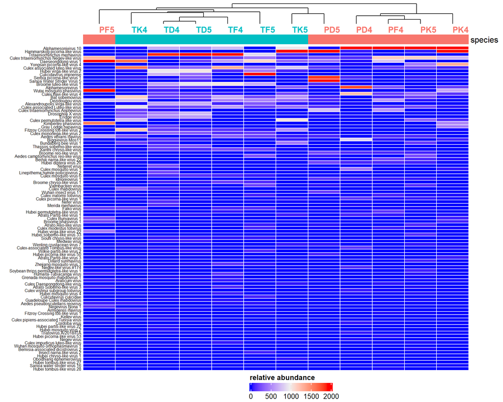

```r
HT1 <- Heatmap(as.matrix(count_otu_taxo_Cx[,2:13]), name = "relative abundance",
               row_names_gp = gpar(fontsize = 6),
               column_names_side = "top",
               column_names_rot = 0,
               heatmap_legend_param = list(direction = "horizontal"),
               row_names_side = "left",
               row_order = order(-count_otu_taxo_Cx$sum_reads),
               top_annotation = HeatmapAnnotation(species = c("C. tritaeniorhynchus","C. tritaeniorhynchus","C. poicilipes","C. tritaeniorhynchus","C. poicilipes","C. tritaeniorhynchus","C. poicilipes","C. poicilipes","C. poicilipes","C. tritaeniorhynchus","C. tritaeniorhynchus","C. poicilipes"),
                                                  col = list(species = c("C. poicilipes" = "#F8766D", "C. tritaeniorhynchus"="#00BFC4"),
                                                             which = "column"),
                                                  show_legend = F),
               rect_gp = gpar(col = "white", lwd = 1),
               column_names_gp = gpar(col = c("#00BFC4","#00BFC4","#F8766D","#00BFC4","#F8766D","#00BFC4","#F8766D","#F8766D","#F8766D","#00BFC4","#00BFC4","#F8766D"), font = 2))

draw(HT1, heatmap_legend_side = "bottom", annotation_legend_side = NULL)
```

- Test de plusieurs méthodes d’ordination par le calcul d’une matrice de distance sur la table d’abondance. (*MDS-nMDS-PCoA*….)

On désigne sous le terme de **MDS (multidimensional scaling)**, un ensemble de techniques permettant de représenter les données d’une matrice de proximité entre objets à l’aide de modèles de distances spatiales. Le **MDS** essaie de représenter des échantillons en 2 dimensions tout en préservant les distances.

Le **nMDS (non Metric Multidimensional scale)** place les points selon les distances calculées avec la méthode choisie (bray/jaccard/sorensen), et représente au mieux les relations de ressemblances entre objets. Dans le **nMDS** non métrique, on cherche à préserver l’ordre des proximités et non leurs valeurs absolues ou relatives. Autrement dit, le but est de représenter les distances entre les objets, en respectant l’ordre entre les proximités plutôt que leurs valeurs exactes.

La **PCoA** équivaut à une analyse en composante principales (ACP) mais préserve la diversité beta au lieu de la variance. La PCoA représente les groupes en utilisant la matrice de distance afin de regrouper les échantillons selon leur « association ».

*Exemple nNMDS/Bray-Curtis data SENEGAL*

```r
set.seed(123)
spe.nmds = metaMDS(abund_OTU_transvers_Cx[,!colnames(abund_OTU_transvers_Cx) %in% c("spe_richness", "nbr_reads","Sample","nbr_mos", "shannon", "simpson", "Host", "Site", "Year")], distance = "bray")
```

```
## Square root transformation
## Wisconsin double standardization
## *** Solution reached
```

```r
spe.nmds
```

```
##
## Call:
## metaMDS(comm = abund_OTU_transvers_Cx[, !colnames(abund_OTU_transvers_Cx) %in%      c("spe_richness", "nbr_reads", "Sample", "nbr_mos", "shannon",          "simpson", "Host", "Site", "Year")], distance = "bray")
##
## global Multidimensional Scaling using monoMDS
##
## Data:     wisconsin(sqrt(abund_OTU_transvers_Cx[, !colnames(abund_OTU_transvers_Cx) %in% c("spe_richness", "nbr_reads", "Sample", "nbr_mos", "shannon", "simpson", "Host", "Site", "Year")]))
## Distance: bray
##
## Dimensions: 2
## Stress:     0.1460129
## Stress type 1, weak ties
## Two convergent solutions found after 20 tries
## Scaling: centring, PC rotation, halfchange scaling
## Species: expanded scores based on 'wisconsin(sqrt(abund_OTU_transvers_Cx[, !colnames(abund_OTU_transvers_Cx) %in% c("spe_richness", "nbr_reads", "Sample", "nbr_mos", "shannon", "simpson", "Host", "Site", "Year")]))'
```

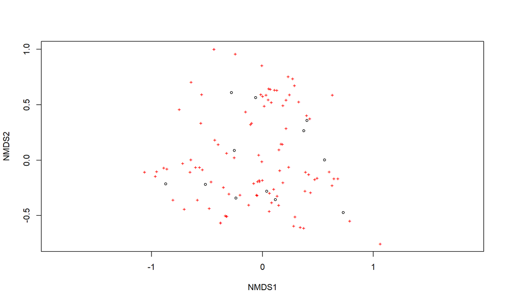

```r
plot(spe.nmds)
```

```r
# extract NMDS scores (x and y coordinates)
data.scores = as.data.frame(scores(spe.nmds))

# add columns to data frame
data.scores$Host = abund_OTU_transvers_Cx$Host
data.scores$Site = abund_OTU_transvers_Cx$Site
data.scores$Year = abund_OTU_transvers_Cx$Year

head(data.scores)
```

|  | NMDS1 | NMDS2 | Host | Site | Year |
| --- | --- | --- | --- | --- | --- |
| PD4 | -0.87218193 | -0.2134590 | C. poicilipes | Diama | 2014 |
| PD5 | 0.11581154 | -0.3570280 | C. poicilipes | Diama | 2015 |
| PF4 | -0.23957336 | -0.3432112 | C. poicilipes | Ferlo | 2014 |
| PF5 | 0.72902403 | -0.4724282 | C. poicilipes | Ferlo | 2015 |
| PK4 | -0.51412389 | -0.2181011 | C. poicilipes | KMS | 2014 |
| PK5 | 0.03936156 | -0.2801490 | C. poicilipes | KMS | 2015 |

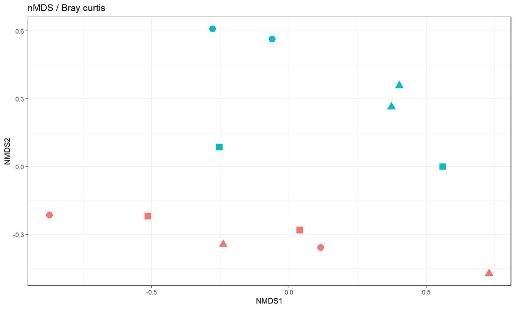

```r
# nMDS
nMDS_plot = ggplot(data.scores, aes(x = NMDS1, y = NMDS2)) +
  geom_point(aes(shape = Site, colour = Host), size = 4) +
  theme(axis.text.y = element_text(colour = "black", size = 12, face = "bold"),
        axis.text.x = element_text(colour = "black", face = "bold", size = 12),
        legend.text = element_text(size = 6, face ="bold", colour ="black"),
        legend.position = "right", axis.title.y = element_text(face = "bold", size = 14),
        axis.title.x = element_text(face = "bold", size = 14, colour = "black"),
        legend.title = element_text(size = 6, colour = "black", face = "bold"),
        panel.background = element_blank(), panel.border = element_rect(colour = "black", fill = NA, size = 1.2),
        legend.key=element_blank(), plot.title = element_text(color="black", size=14, face="bold.italic")) +
  ggtitle("nMDS / Bray curtis") +
  labs(x = "NMDS1", y = "NMDS2")  +
  scale_colour_manual(values = c("#F8766D", "#00BFC4", "#009E73")) + theme_bw() + theme(legend.position = "none")
nMDS_plot
```

*Exemple PCoA/Bray-Curtis data SENEGAL*

```r
# Transformation matrice bray-curtis
spe.bray<-vegdist(abund_OTU_transvers_Cx[,!colnames(abund_OTU_transvers_Cx) %in% c("spe_richness", "nbr_reads","Sample","nbr_mos", "shannon", "simpson", "Host", "Site", "Year")], method="bray")
spe.bray
```

```
##           PD4       PD5       PF4       PF5       PK4       PK5       TD4
## PD5 0.9682807
## PF4 0.6971984 0.7958871
## PF5 0.9787408 0.8583456 0.8322459
## PK4 0.7646237 0.7191033 0.4387796 0.8469308
## PK5 0.6974376 0.8814373 0.2574623 0.9153413 0.3903010
## TD4 0.7712603 0.9418620 0.8415766 0.9850261 0.8489397 0.8278310
## TD5 0.8572858 0.8801325 0.8560616 0.9534993 0.9107081 0.8569102 0.3607216
## TF4 0.9244705 0.8689642 0.8766030 0.8463445 0.9546617 0.8765134 0.8418737
## TF5 0.9819942 0.8258135 0.8555222 0.7326594 0.9550218 0.8953270 0.7473699
## TK4 0.9743679 0.8316359 0.8274181 0.6991281 0.9472738 0.8356362 0.8280006
## TK5 0.7865964 0.6833520 0.7966039 0.8868651 0.7249280 0.7483579 0.7830533
##           TD5       TF4       TF5       TK4
## PD5
## PF4
## PF5
## PK4
## PK5
## TD4
## TD5
## TF4 0.6887704
## TF5 0.6833517 0.5436308
## TK4 0.7619412 0.6337373 0.6705511
## TK5 0.7082158 0.7310793 0.8126667 0.5172863
```

Construction de la PCoA :

```r
pcoa <- cmdscale(spe.bray, k=3, eig = T, add = T) # avec k=3 ici donc sélection de trois axes, mais visualisation avec 2 seulement avec PCoA (pour simplification)
pcoa %>% head()
```

```
## $points
##            [,1]         [,2]         [,3]
## PD4  0.31898285  0.284917152 -0.095818760
## PD5  0.01778839 -0.290512563  0.444249650
## PF4  0.41356949 -0.069678453 -0.147139871
## PF5 -0.13819115 -0.442468394 -0.305953139
## PK4  0.48507464 -0.104818579  0.061590105
## PK5  0.44285188  0.009925664 -0.120779002
## TD4 -0.11927073  0.499743102 -0.006005794
## TD5 -0.26286506  0.413150765  0.057711220
## TF4 -0.37195959 -0.024706429 -0.096539397
## TF5 -0.40038408 -0.060544533 -0.194061391
## TK4 -0.32557668 -0.189326692  0.038165364
## TK5 -0.06001995 -0.025681040  0.364581016
##
## $eig
##  [1]  1.215206e+00  8.385110e-01  5.248996e-01  4.316936e-01  3.817891e-01
##  [6]  3.325263e-01  1.627872e-01  1.315949e-01  7.299114e-02  2.631405e-02
## [11]  8.865175e-17 -2.351641e-17
##
## $x
## NULL
##
## $ac
## [1] 0.06110151
##
## $GOF
## [1] 0.6261342 0.6261342
```

```r
positions <- pcoa$points
colnames(positions) <- c("pcoa1", "pcoa2", "pcoa3")
positions %>% head()
```

```
##           pcoa1        pcoa2       pcoa3
## PD4  0.31898285  0.284917152 -0.09581876
## PD5  0.01778839 -0.290512563  0.44424965
## PF4  0.41356949 -0.069678453 -0.14713987
## PF5 -0.13819115 -0.442468394 -0.30595314
## PK4  0.48507464 -0.104818579  0.06159010
## PK5  0.44285188  0.009925664 -0.12077900
```

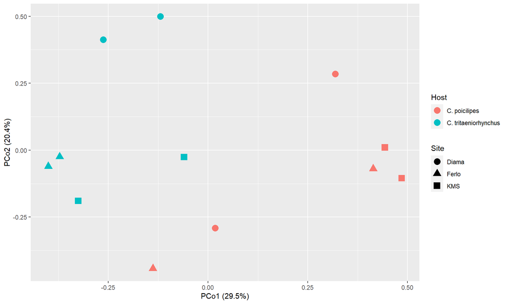

```r
percent_explained <- 100 * pcoa$eig / sum(pcoa$eig)

pretty_pe <- format(round(percent_explained[1:3], digits =1), nsmall = 1, trim = T)

labs <- c(glue("PCo1 ({pretty_pe[1]}%)"),
          glue("PCo2 ({pretty_pe[2]}%)"),
          glue("PCo3 ({pretty_pe[3]}%)"))

positions <- as.data.frame(positions)
positions$Host <- abund_OTU_transvers_Cx$Host
positions$Site <- abund_OTU_transvers_Cx$Site
positions$Year <- abund_OTU_transvers_Cx$Year

positions %>%
  as_tibble(rownames="samples") %>%
  ggplot(aes(x=pcoa1, y=pcoa2, color=Host, shape=Site)) +
  geom_point(size = 4) +
  labs(x = labs[1], y = labs[2])
```

Créer un scree plot pour observer la quantité de variations de chaque axe :

*Ici, les deux premiers axes représentent quasiment 50% de la variation totale (si on veut prendre plus de variation on rajoute des axes)*

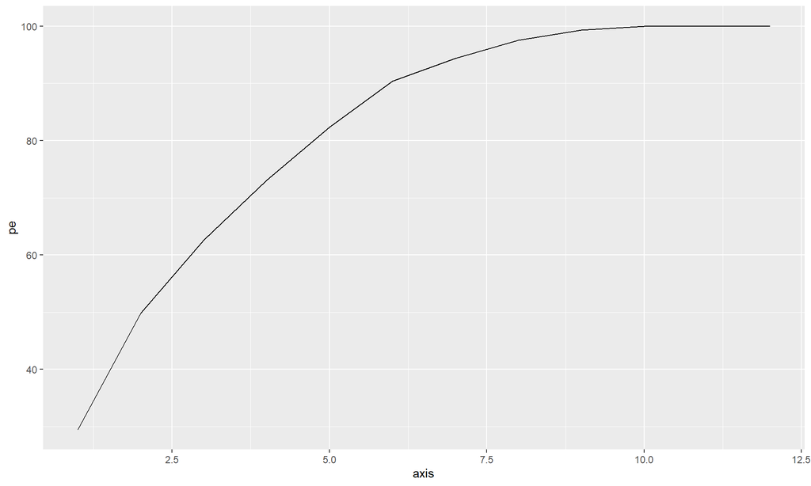

```r
tibble(pe = cumsum(percent_explained),
       axis = 1:length(percent_explained)) %>%
  ggplot(aes(x=axis, y=pe)) +
  geom_line()
```

Construction d’une PCoA en 3D pour visualiser plus facilement plus de 2 axes (ajout de la dimension z) :

```r
positions <- positions %>%
  mutate(Host = factor(Host, levels=c("C. poicilipes", "C. tritaeniorhynchus")),
  Host_color = case_when(Host == "C. poicilipes" ~ "blue",
                         Host == "C. tritaeniorhynchus" ~ "red",
                         TRUE ~ NA_character_))

plot3d(x=positions$pcoa1, y=positions$pcoa2, z=positions$pcoa3,
       xlab = labs[1], ylab = labs[2], zlab = labs[3],
       col=positions$Host_color, type="s", size=1)
```

## 2.6 : Pour aller plus loin

### 2.6.1 : Différences indices de dissimilarité (diversité Beta)

*Revoir la définition des indices écologiques dans la partie “**2.4.4 : Exploration de la biodiversité Beta**”*

*Si question sur cette partie, demander à Serafin ou Côme*

```r
## Jaccard, Bray-Curtis and Sorensen indexes
jacc_tab <- vegdist(abund_OTU_transvers_Cx[,!colnames(abund_OTU_transvers_Cx) %in% c("spe_richness", "nbr_reads", "Sample", "nbr_mos", "shannon", "simpson", "Host", "Site", "Year")], method="jaccard", binary = T)
Bray_tab <- vegdist(abund_OTU_transvers_Cx[,!colnames(abund_OTU_transvers_Cx) %in% c("spe_richness", "nbr_reads", "Sample", "nbr_mos", "shannon", "simpson", "Host", "Site", "Year")], method="bray")
Sor_tab <- vegdist(abund_OTU_transvers_Cx[,!colnames(abund_OTU_transvers_Cx) %in% c("spe_richness", "nbr_reads", "Sample", "nbr_mos", "shannon", "simpson", "Host", "Site", "Year")], method="bray", binary = T)

# Transformation in matrix
jacc_tab2 <- as.matrix(jacc_tab)
Bray_tab2 <- as.matrix(Bray_tab)
Sor_tab2 <- as.matrix(Sor_tab)
jacc_tab3 <- melt(as.matrix(jacc_tab), varnames = c("row", "col"))
Bray_tab3 <- melt(as.matrix(Bray_tab), varnames = c("row", "col"))
Sor_tab3 <- melt(as.matrix(Sor_tab), varnames = c("row", "col"))

# Download in csv files
write.csv2(jacc_tab2, file = "jaccard_OTU.csv")
write.csv2(Bray_tab2, file = "BrayCurtis_OTU.csv")
write.csv2(Sor_tab2, file = "Sorensen_OTU.csv")
write.csv2(jacc_tab3, file = "jaccard_OTU_2.csv")
write.csv2(Bray_tab3, file = "BrayCurtis_OTU_2.csv")
write.csv2(Sor_tab3, file = "Sorensen_OTU_2.csv")

## the two files have been merged in dist_matrixes_Jac_Bray.xlsx (reports folder)
dist_matrixes_Jac_Bray_OTU <- read_excel(Dist_table.file) # in reports folder

# Fig. with all point/all librarie comparison.
fig_betaindexes <- dist_matrixes_Jac_Bray_OTU %>%
  filter(value != 0) %>%
  ggplot() +
  geom_jitter(aes(x = row, y = value, colour = col), width = 0.1) +
  xlab("") +
  ylab("") +
  theme_bw() +
  facet_wrap(~ index)
fig_betaindexes <- fig_betaindexes +
  theme(axis.text.x = element_text(size = 9, angle = 25, hjust = 1, debug = FALSE),
        legend.title = element_blank())

# statistical analysis of beta indexes: compare BC and Jaccard/Sorensen depending on species
dist_Jac_Bray2 <- read_excel(Dist_matrix.file) # in reports folder

# change the dataframe structure
dist_Jac_Bray3 <- dist_Jac_Bray2 %>%
  pivot_longer(., starts_with(c("P", "T")),
               names_to = "sample",
               values_to = "estimate",
               values_drop_na = TRUE) %>%
  separate(., col = "sample", into = c("Nothing1", "Host1", "habitat1", "year1"),
           sep = "", remove = FALSE) %>%
  separate(., col = "row", into = c("Nothing2", "Host2", "habitat2", "year2"),
           sep = "", remove = FALSE)

dist_Jac_Bray3 <- dist_Jac_Bray3[,! colnames(dist_Jac_Bray3) %in% c("Nothing1", "Nothing2")]

dist_Jac_Bray3 <- dist_Jac_Bray3 %>%
  mutate(Host = if_else(Host1 == Host2, "same", "different"))
dist_Jac_Bray3 <- dist_Jac_Bray3 %>%
  mutate(Habitat = if_else(habitat1 == habitat2, "same", "different"))
dist_Jac_Bray3 <- dist_Jac_Bray3 %>%
  mutate(Year = if_else(year1 == year2, "same", "different"))

dist_Jac <- dist_Jac_Bray3 %>% filter(index == "jaccard")
dist_BC <- dist_Jac_Bray3 %>% filter(index == "bray-curtis")
dist_sor <- dist_Jac_Bray3 %>% filter(index == "sorensen")

# statistic tests
wilcox.test(dist_Jac$estimate ~ dist_Jac$Host) # p-value = 0.01467
```

```
##
##  Wilcoxon rank sum test with continuity correction
##
## data:  dist_Jac$estimate by dist_Jac$Host
## W = 730, p-value = 0.01467
## alternative hypothesis: true location shift is not equal to 0
```

```r
wilcox.test(dist_BC$estimate ~ dist_BC$Host) # p-value = 2.877e-05
```

```
##
##  Wilcoxon rank sum exact test
##
## data:  dist_BC$estimate by dist_BC$Host
## W = 854, p-value = 2.877e-05
## alternative hypothesis: true location shift is not equal to 0
```

```r
wilcox.test(dist_sor$estimate ~ dist_sor$Host) # p-value = 0.01467
```

```
##
##  Wilcoxon rank sum test with continuity correction
##
## data:  dist_sor$estimate by dist_sor$Host
## W = 730, p-value = 0.01467
## alternative hypothesis: true location shift is not equal to 0
```

```r
kruskal.test(dist_Jac$estimate ~ dist_Jac$Habitat) # p-value = 0.1116
```

```
##
##  Kruskal-Wallis rank sum test
##
## data:  dist_Jac$estimate by dist_Jac$Habitat
## Kruskal-Wallis chi-squared = 2.5314, df = 1, p-value = 0.1116
```

```r
kruskal.test(dist_BC$estimate ~ dist_BC$Habitat) # p-value = 0.4986
```

```
##
##  Kruskal-Wallis rank sum test
##
## data:  dist_BC$estimate by dist_BC$Habitat
## Kruskal-Wallis chi-squared = 0.45792, df = 1, p-value = 0.4986
```

```r
kruskal.test(dist_Jac$estimate ~ dist_Jac$Year) # p-value = 0.7281
```

```
##
##  Kruskal-Wallis rank sum test
##
## data:  dist_Jac$estimate by dist_Jac$Year
## Kruskal-Wallis chi-squared = 0.12091, df = 1, p-value = 0.7281
```

```r
kruskal.test(dist_BC$estimate ~ dist_BC$Year) # p-value = 0.3882
```

```
##
##  Kruskal-Wallis rank sum test
##
## data:  dist_BC$estimate by dist_BC$Year
## Kruskal-Wallis chi-squared = 0.74444, df = 1, p-value = 0.3882
```

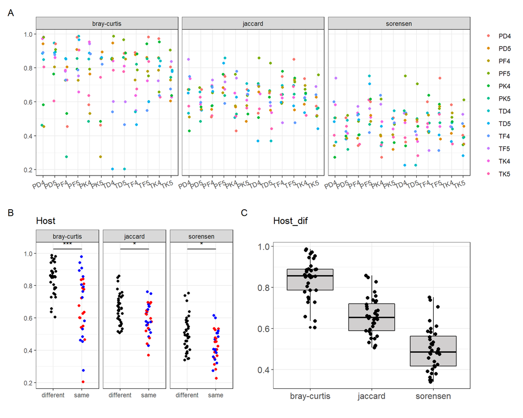

```r
# Fig. compare indexes depending on shared Host or Habitat
fig_betaindexes_Host <- dist_Jac_Bray3 %>%
  ggplot(aes(x = Host, y = estimate)) +
  geom_jitter(aes(colour = if_else(Host == "same", Host1, "black")), width = 0.1) +
  scale_color_manual(name = "Host1", values = c("black", "blue", "red", "purple")) +
  xlab("") +
  ylab("") +
  theme_bw() +
  facet_wrap(~ index) +
  geom_signif(comparisons = list(c("different", "same")), test = "wilcox.test", map_signif_level=TRUE, tip_length = 0, col="black")
fig_betaindexes_Host <- fig_betaindexes_Host + theme(legend.position = "none") +
  ggtitle("Host")

fig_betaindexes_Habitat <- dist_Jac_Bray3 %>%
  ggplot(aes(x = Habitat, y = estimate)) +
  geom_jitter(aes(colour = if_else(Habitat == "same", habitat1, "black")), width = 0.1) +
  scale_color_manual(name = "habitat1", values = c("black", "blue", "red", "purple")) +
  xlab("") +
  ylab("") +
  theme_bw() +
  facet_wrap(~ index) +
  geom_signif(comparisons = list(c("different", "same")), test = "wilcox.test", map_signif_level=TRUE, tip_length = 0, col="black")
fig_betaindexes_Habitat <- fig_betaindexes_Habitat + theme(legend.position = "none") +
  ggtitle("Habitat")

# just Host BC vs Jac
fig_betaindexes_Host_dif <- dist_Jac_Bray3 %>%
  filter(Host %in% "different") %>%
  ggplot(aes(x = index, y = estimate)) +
  geom_boxplot(fill='#d1cfcf', color="black") +
  geom_jitter(aes(colour = if_else(Host == "same", Host1, "black")), width = 0.1, size = 2) +
  scale_color_manual(name = "Host1", values = c("black", "blue", "red", "purple")) +
  xlab("") +
  ylab("") +
  theme_bw() +
 # geom_hline(yintercept=0.5, linetype="dashed",
 #           color = "red", size=1) +
  theme(axis.text.x = element_text(size = 12),
        axis.text.y = element_text(size = 12))
fig_betaindexes_Host_dif <- fig_betaindexes_Host_dif + theme(legend.position = "none") +
  ggtitle("Host_dif")

fig_betaindexes/(fig_betaindexes_Host|fig_betaindexes_Host_dif) +
  plot_annotation(tag_levels = 'A')
```

```r
# Moyenne Bray-Curtis
dist_Jac_Bray3 %>%
  filter(Host %in% "different") %>%
  filter(index %in% "bray-curtis") %>%
  summarise(index = median(estimate, na.rm = TRUE)) # mean = 0.8569679
```

| index |
| --- |
| 0.8569679 |

```r
# Moyenne Jaccard
dist_Jac_Bray3 %>%
  filter(Host %in% "different") %>%
  filter(index %in% "jaccard") %>%
  summarise(index = median(estimate, na.rm = TRUE)) # mean = 0.6545107
```

| index |
| --- |
| 0.6545107 |

```r
# Moyenne Sorensen
dist_Jac_Bray3 %>%
  filter(Host %in% "different") %>%
  filter(index %in% "sorensen") %>%
  summarise(index = median(estimate, na.rm = TRUE)) # mean = 0.4864595
```

| index |
| --- |
| 0.4864595 |

### 2.6.2 : Betadisperser pour tester l’homogénéité des dispersions multivariées

**Betadisper tests** whether two or more groups (for example, grazed and ungrazed sites) are homogeneously dispersed in relation to their species in studied samples. This test can be done to see if one group has more compositional variance than another. Moreover, homogeneity of dispersion among groups is very advisable to have if you want to test if two or more groups have different compositions, which is tested by `adonis`.

Betadisper first calculates the average distance of group members to the group centroid in multivariate space (generated by a distance matrix). Then, an `ANOVA` is done to test if the dispersions (variances) of groups are different.

```r
# Host :
# Bray-Curtis distances between samples
dis <- vegdist(abund_OTU_transvers_Cx[,!colnames(abund_OTU_transvers_Cx) %in% c("spe_richness", "nbr_reads", "Sample", "nbr_mos", "shannon", "simpson", "Host", "Site", "Year")])

# Calculate multivariate dispersions
mod <- betadisper(dis, abund_OTU_transvers_Cx$Host)
mod
```

```
##
##  Homogeneity of multivariate dispersions
##
## Call: betadisper(d = dis, group = abund_OTU_transvers_Cx$Host)
##
## No. of Positive Eigenvalues: 10
## No. of Negative Eigenvalues: 1
##
## Average distance to median:
##        C. poicilipes C. tritaeniorhynchus
##               0.4643               0.4500
##
## Eigenvalues for PCoA axes:
## (Showing 8 of 11 eigenvalues)
##  PCoA1  PCoA2  PCoA3  PCoA4  PCoA5  PCoA6  PCoA7  PCoA8
## 1.0978 0.7530 0.4624 0.3755 0.3272 0.2831 0.1294 0.1008
```

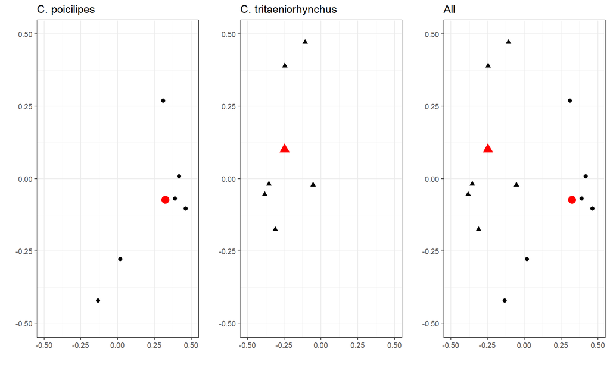

```r
# Visualization of the multivariate homogeneity of group dispersions
# extract the centroids and the site points in multivariate space.
centroids<-data.frame(grps=rownames(mod$centroids),data.frame(mod$centroids))
vectors<-data.frame(group=mod$group,data.frame(mod$vectors))

# to create the lines from the centroids to each point we will put it in a format that ggplot can handle
seg.data<-cbind(vectors[,1:3],centroids[rep(1:nrow(centroids),as.data.frame(table(vectors$group))$Freq),2:3])
names(seg.data)<-c("group","v.PCoA1","v.PCoA2","PCoA1","PCoA2")

# create the convex hulls of the outermost points
grp1.hull<-seg.data[seg.data$group=="C. poicilipes",1:3][chull(seg.data[seg.data$group=="C. poicilipes",2:3]),]
grp2.hull<-seg.data[seg.data$group=="C. tritaeniorhynchus",1:3][chull(seg.data[seg.data$group=="C. tritaeniorhynchus",2:3]),]
all.hull<-rbind(grp1.hull,grp2.hull)

# Graphic

panel.a <- ggplot() +
  geom_point(data=centroids[1,1:3], aes(x=PCoA1,y=PCoA2),size=4,colour="red",shape=16) +
  geom_point(data=seg.data[1:6,], aes(x=v.PCoA1,y=v.PCoA2),size=2,shape=16) +
  labs(title="C. poicilipes",x="",y="") +
  coord_cartesian(xlim = c(-0.5,0.5), ylim = c(-0.5,0.5)) +
  theme_bw() +
  theme(legend.position="none")

panel.b <- ggplot() +
  geom_point(data=centroids[2,1:3], aes(x=PCoA1,y=PCoA2),size=4,colour="red",shape=17) +
  geom_point(data=seg.data[7:12,], aes(x=v.PCoA1,y=v.PCoA2),size=2,shape=17) +
  labs(title="C. tritaeniorhynchus",x="",y="") +
  coord_cartesian(xlim = c(-0.5,0.5), ylim = c(-0.5,0.5)) +
  theme_bw() +
  theme(legend.position="none")

panel.c <- ggplot() +
  geom_point(data=centroids[,1:3], aes(x=PCoA1,y=PCoA2,shape=grps),size=4,colour="red") +
  geom_point(data=seg.data, aes(x=v.PCoA1,y=v.PCoA2,shape=group),size=2) +
  labs(title="All",x="",y="") +
  coord_cartesian(xlim = c(-0.5,0.5), ylim = c(-0.5,0.5)) +
  theme_bw() +
  theme(legend.position="none")

grid.arrange(panel.a,panel.b,panel.c,nrow=1)
```

```r
# Site :
# Calculate multivariate dispersions
mod <- betadisper(dis, abund_OTU_transvers_Cx$Site)
mod
```

```
##
##  Homogeneity of multivariate dispersions
##
## Call: betadisper(d = dis, group = abund_OTU_transvers_Cx$Site)
##
## No. of Positive Eigenvalues: 10
## No. of Negative Eigenvalues: 1
##
## Average distance to median:
##  Diama  Ferlo    KMS
## 0.4793 0.4766 0.4357
##
## Eigenvalues for PCoA axes:
## (Showing 8 of 11 eigenvalues)
##  PCoA1  PCoA2  PCoA3  PCoA4  PCoA5  PCoA6  PCoA7  PCoA8
## 1.0978 0.7530 0.4624 0.3755 0.3272 0.2831 0.1294 0.1008
```

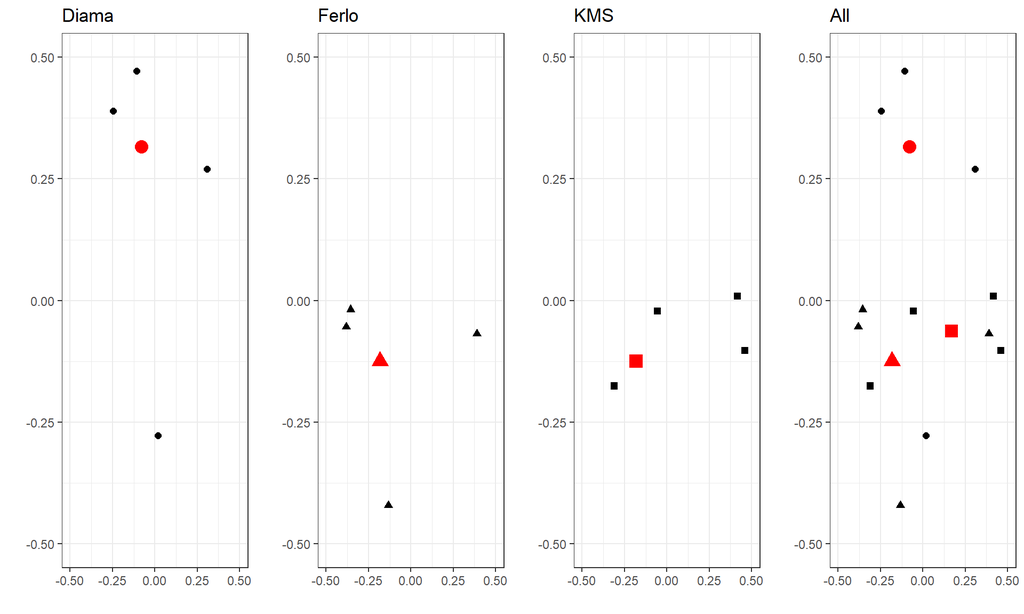

```r
# Visualization of the multivariate homogeneity of group dispersions
# extract the centroids and the site points in multivariate space.
centroids <- data.frame(grps=rownames(mod$centroids),data.frame(mod$centroids))
vectors <- data.frame(group=mod$group,data.frame(mod$vectors))

# to create the lines from the centroids to each point we will put it in a format that ggplot can handle
seg.data <- cbind(vectors[,1:3],centroids[rep(1:nrow(centroids),as.data.frame(table(vectors$group))$Freq),2:3])
names(seg.data) <- c("group","v.PCoA1","v.PCoA2","PCoA1","PCoA2")

# create the convex hulls of the outermost points
grp1.hull <- seg.data[seg.data$group=="Diama",1:3][chull(seg.data[seg.data$group=="Diama",2:3]),]
grp2.hull <- seg.data[seg.data$group=="Ferlo",1:3][chull(seg.data[seg.data$group=="Ferlo",2:3]),]
grp3.hull <- seg.data[seg.data$group=="KMS",1:3][chull(seg.data[seg.data$group=="KMS",2:3]),]
all.hull <- rbind(grp1.hull,grp2.hull,grp3.hull)

# Graphic

panel.a <- ggplot() +
  geom_point(data=centroids[1,1:3], aes(x=PCoA1,y=PCoA2),size=4,colour="red",shape=16) +
  geom_point(data=seg.data[c(1:2,7:8),], aes(x=v.PCoA1,y=v.PCoA2),size=2,shape=16) +
  labs(title="Diama",x="",y="") +
  coord_cartesian(xlim = c(-0.5,0.5), ylim = c(-0.5,0.5)) +
  theme_bw() +
  theme(legend.position="none")

panel.b <- ggplot() +
  geom_point(data=centroids[2,1:3], aes(x=PCoA1,y=PCoA2),size=4,colour="red",shape=17) +
  geom_point(data=seg.data[c(3:4,9:10),], aes(x=v.PCoA1,y=v.PCoA2),size=2,shape=17) +
  labs(title="Ferlo",x="",y="") +
  coord_cartesian(xlim = c(-0.5,0.5), ylim = c(-0.5,0.5)) +
  theme_bw() +
  theme(legend.position="none")

panel.c <- ggplot() +
  geom_point(data=centroids[2,1:3], aes(x=PCoA1,y=PCoA2),size=4,colour="red",shape=15) +
  geom_point(data=seg.data[c(5:6,11:12),], aes(x=v.PCoA1,y=v.PCoA2),size=2,shape=15) +
  labs(title="KMS",x="",y="") +
  coord_cartesian(xlim = c(-0.5,0.5), ylim = c(-0.5,0.5)) +
  theme_bw() +
  theme(legend.position="none")

panel.d <- ggplot() +
  geom_point(data=centroids[,1:3], aes(x=PCoA1,y=PCoA2,shape=grps),size=4,colour="red") +
  geom_point(data=seg.data, aes(x=v.PCoA1,y=v.PCoA2,shape=group),size=2) +
  labs(title="All",x="",y="") +
  coord_cartesian(xlim = c(-0.5,0.5), ylim = c(-0.5,0.5)) +
  theme_bw() +
  theme(legend.position="none")

grid.arrange(panel.a,panel.b,panel.c,panel.d,nrow=1)
```

```r
# Year :
# Calculate multivariate dispersions
mod <- betadisper(dis, abund_OTU_transvers_Cx$Year)
mod
```

```
##
##  Homogeneity of multivariate dispersions
##
## Call: betadisper(d = dis, group = abund_OTU_transvers_Cx$Year)
##
## No. of Positive Eigenvalues: 10
## No. of Negative Eigenvalues: 1
##
## Average distance to median:
##   2014   2015
## 0.5281 0.5307
##
## Eigenvalues for PCoA axes:
## (Showing 8 of 11 eigenvalues)
##  PCoA1  PCoA2  PCoA3  PCoA4  PCoA5  PCoA6  PCoA7  PCoA8
## 1.0978 0.7530 0.4624 0.3755 0.3272 0.2831 0.1294 0.1008
```

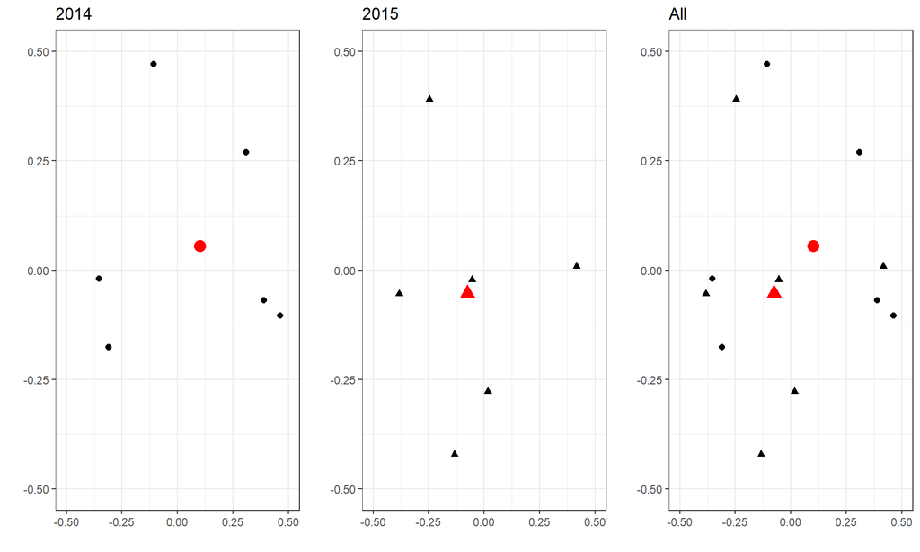

```r
# Visualization of the multivariate homogeneity of group dispersions
# extract the centroids and the site points in multivariate space.
centroids <- data.frame(grps=rownames(mod$centroids),data.frame(mod$centroids))
vectors <- data.frame(group=mod$group,data.frame(mod$vectors))

# to create the lines from the centroids to each point we will put it in a format that ggplot can handle
seg.data <- cbind(vectors[,1:3],centroids[rep(1:nrow(centroids),as.data.frame(table(vectors$group))$Freq),2:3])
names(seg.data) <- c("group","v.PCoA1","v.PCoA2","PCoA1","PCoA2")

# create the convex hulls of the outermost points
grp1.hull <- seg.data[seg.data$group=="2014",1:3][chull(seg.data[seg.data$group=="2014",2:3]),]
grp2.hull <- seg.data[seg.data$group=="2015",1:3][chull(seg.data[seg.data$group=="2015",2:3]),]
all.hull <- rbind(grp1.hull,grp2.hull)

# Graphic

panel.a <- ggplot() +
  geom_point(data=centroids[1,1:3], aes(x=PCoA1,y=PCoA2),size=4,colour="red",shape=16) +
  geom_point(data=seg.data[c(1,3,5,7,9,11),], aes(x=v.PCoA1,y=v.PCoA2),size=2,shape=16) +
  labs(title="2014",x="",y="") +
  coord_cartesian(xlim = c(-0.5,0.5), ylim = c(-0.5,0.5)) +
  theme_bw() +
  theme(legend.position="none")

panel.b <- ggplot() +
  geom_point(data=centroids[2,1:3], aes(x=PCoA1,y=PCoA2),size=4,colour="red",shape=17) +
  geom_point(data=seg.data[c(2,4,6,8,10,12),], aes(x=v.PCoA1,y=v.PCoA2),size=2,shape=17) +
  labs(title="2015",x="",y="") +
  coord_cartesian(xlim = c(-0.5,0.5), ylim = c(-0.5,0.5)) +
  theme_bw() +
  theme(legend.position="none")

panel.c <- ggplot() +
  geom_point(data=centroids[,1:3], aes(x=PCoA1,y=PCoA2,shape=grps),size=4,colour="red") +
  geom_point(data=seg.data, aes(x=v.PCoA1,y=v.PCoA2,shape=group),size=2) +
  labs(title="All",x="",y="") +
  coord_cartesian(xlim = c(-0.5,0.5), ylim = c(-0.5,0.5)) +
  theme_bw() +
  theme(legend.position="none")

grid.arrange(panel.a,panel.b,panel.c,nrow=1)
```

### 2.6.3 : Créer une cartographie des points d’échantillonnages des données

Plus d’informations [ici](https://ahurford.github.io/quant-guide-all-courses/making-maps.html#introduction-4) :

*Nécessite certaines librairies spécifiques à installer/charger :*

```r
#install.packages("devtools") # install + load packages
#devtools::install_github("ropensci/rnaturalearthhires")
library("rnaturalearth")
library("ggspatial")
library("cowplot")
library("ggrepel")
```

Créer la carte du Sénégal (dans le cadre de cette étude) :

```r
senegal_map <- ne_states(country = c("senegal", "gambia", "mauritania", "mali", "guinea bissau", "guinea"), returnclass = "sf") # chargement des pays proches du sénégal pour faire une carte plus large
senegal_map
```

|  | featurecla | scalerank | adm1_code | diss_me | iso_3166_2 | wikipedia | iso_a2 | adm0_sr | name | name_alt | name_local | type | type_en | code_local | code_hasc | note | hasc_maybe | region | region_cod | provnum_ne | gadm_level | check_me | datarank | abbrev | postal | area_sqkm | sameascity | labelrank | name_len | … |
| --- | --- | --- | --- | --- | --- | --- | --- | --- | --- | --- | --- | --- | --- | --- | --- | --- | --- | --- | --- | --- | --- | --- | --- | --- | --- | --- | --- | --- | --- | --- |
| 356 | Admin-1 scale rank | 6 | GIN-5636 | 5636 | GN-FA | NA | GN | 1 | Faranah | NA | NA | Préfecture | Prefecture | NA | GN.FA | NA | NA | Faranah | GN.F | 0 | 0 | 13 | 8 | NA | NA | 0 | 7 | 7 | 7 | … |
| 357 | Admin-1 scale rank | 6 | GIN-5643 | 5643 | GN-KD | NA | GN | 1 | Kindia | NA | NA | Préfecture | Prefecture | NA | GN.KD | NA | NA | Kindia | GN.D | 0 | 0 | 13 | 8 | NA | NA | 0 | 7 | 7 | 6 | … |
| 358 | Admin-1 scale rank | 6 | GIN-5653 | 5653 | GN-MM | NA | GN | 1 | Mamou | NA | NA | Préfecture | Prefecture | NA | GN.MM | NA | NA | Mamou | GN.M | 0 | 0 | 13 | 8 | NA | NA | 0 | 7 | 7 | 5 | … |
| 359 | Admin-1 scale rank | 6 | GIN-5632 | 5632 | GN-DB | NA | GN | 1 | Dabola | NA | NA | Préfecture | Prefecture | NA | GN.DB | NA | NA | Faranah | GN.F | 0 | 0 | 13 | 8 | NA | NA | 0 | 7 | 7 | 6 | … |
| 360 | Admin-1 scale rank | 6 | GIN-5637 | 5637 | GN-FO | NA | GN | 1 | Forécariah | NA | NA | Préfecture | Prefecture | NA | GN.FO | NA | NA | Kindia | GN.D | 0 | 0 | 13 | 8 | NA | NA | 0 | 7 | 7 | 10 | … |
| 361 | Admin-1 scale rank | 6 | GIN-5640 | 5640 | GN-GU | NA | GN | 1 | Guéckédou | NA | NA | Préfecture | Prefecture | NA | GN.GU | NA | NA | Nzérékoré | GN.N | 0 | 0 | 13 | 8 | NA | NA | 0 | 7 | 7 | 9 | … |
| 435 | Admin-1 scale rank | 6 | GIN-5641 | 5641 | GN-K | NA | GN | 1 | Kankan | NA | NA | Préfecture | Prefecture | NA | GN.KA | NA | NA | Kankan | GN.K | 0 | 0 | 13 | 8 | NA | NA | 0 | 6 | 6 | 6 | … |
| 436 | Admin-1 scale rank | 6 | GIN-5654 | 5654 | GN-MD | NA | GN | 1 | Mandiana | NA | NA | Préfecture | Prefecture | NA | GN.MD | NA | NA | Kankan | GN.K | 0 | 0 | 13 | 8 | NA | NA | 0 | 6 | 6 | 8 | … |
| 437 | Admin-1 scale rank | 6 | GIN-5627 | 5627 | GN-BE | NA | GN | 1 | Beyla | NA | NA | Préfecture | Prefecture | NA | GN.BE | NA | NA | Nzérékoré | GN.N | 0 | 0 | 13 | 8 | NA | NA | 0 | 7 | 7 | 5 | … |
| 440 | Admin-1 scale rank | 6 | GIN-5650 | 5650 | GN-LO | NA | GN | 1 | Lola | NA | NA | Préfecture | Prefecture | NA | GN.LO | NA | NA | Nzérékoré | GN.N | 0 | 0 | 13 | 8 | NA | NA | 0 | 7 | 7 | 4 | … |

[output cut: 75 more lines]

Créer la carte du Monde :

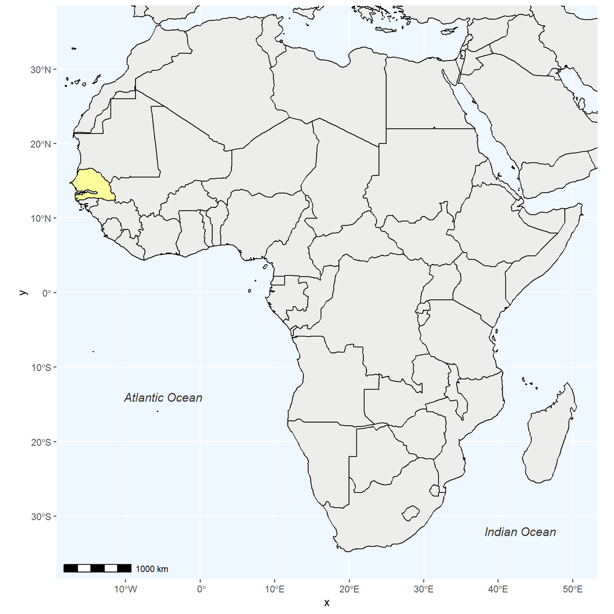

```r
# load world map
world <- ne_countries(scale = "medium", returnclass = "sf")

# create new column to put a discrete value on Senegal
world$SEN <- world$name == "Senegal"
world$SEN[world$SEN == TRUE] <- 1
world$SEN[world$SEN == FALSE] <- 0

# plot world_map with senegal highlight
map_World <- ggplot() +
  geom_sf(data = world, colour = "black", fill = ifelse(world$name == "Senegal", '#FCFC9C', '#ededeb')) + # highlight senegal
  annotation_scale(location = "bl", width_hint = 0.2) + # put scale on map
  coord_sf(xlim = c(-16, 50), ylim = c(-35, 35)) + # Zoom on the area of interest
  theme(panel.background = element_rect(fill = "aliceblue"),
        plot.background = element_blank()) + # put blue background (for sea)
  #theme_void() +
  annotate(geom = "text", x = c(-5,43), y = c(-14,-32), label = c("Atlantic Ocean", "Indian Ocean"),fontface = "italic", color = "grey22", size = 4) # annotate Ocean
map_World
```

Charger un fichier de métadonnées comprenant la position géographique des sites (Latitude et Longitude) :

```r
SupData_merge <- read_excel(Map.file)
SupData_merge
```

| Region | Latitude | Longitude |
| --- | --- | --- |
| Younoufere | 15.27580 | -14.44534 |
| Diama | 16.21151 | -16.39212 |
| KMS | 15.94770 | -15.93949 |

Créer la carte récapitulative avec la carte du Sénégal et la carte du monde intégrée pour la localisation du Sénégal à l’échelle globale

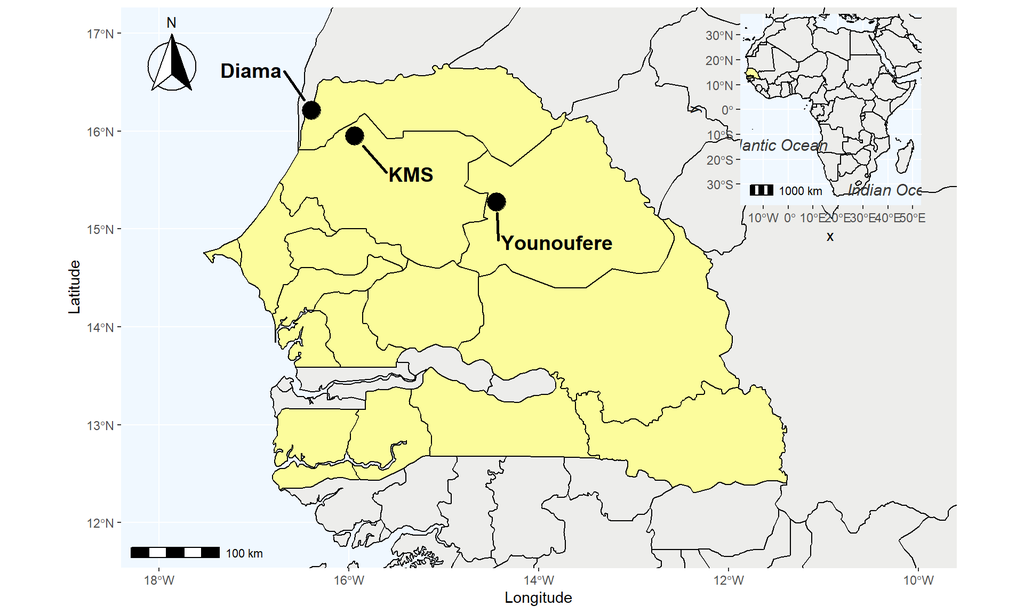

```r
# plot senegal with point and world map in top right
ggdraw(ggplot() +
  geom_sf(data = senegal_map, colour = "black", fill = ifelse(senegal_map$iso_a2 == "SN", '#FCFC9C', '#ededeb')) + # highlight senegal
  theme(panel.background = element_rect(fill = "aliceblue")) + # put blue background (for sea)
  geom_point(aes(x=Longitude, y=Latitude, group=Region), data=SupData_merge, size = 6) + # put point of region of interest
  geom_text_repel(aes(x=Longitude, y=Latitude, label = Region), data=SupData_merge, size = 5, fontface = 2, box.padding = unit(1.5, "lines"), point.padding = unit(1.5, "lines"), segment.size  = 1) + # put lines for point
  coord_sf(xlim = c(-18, -10), ylim = c(11.8, 17)) + # zoom coord
  annotation_scale(location = "bl", width_hint = 0.2) + # put scale on map
  annotation_north_arrow(location = "tl", which_north = "true",
                         height = unit(2, "cm"), width = unit(2, "cm"),
                         style = north_arrow_fancy_orienteering)) + # put arrow on map
  draw_plot(map_World, width = 0.4, height = 0.4, x = 0.585, y = 0.59) # put world map on top right
```

# References

Allaire, JJ, Jeffrey Horner, Yihui Xie, Vicent Marti, and Natacha Porte. 2019. *Markdown: Render Markdown with the c Library Sundown*. https://github.com/rstudio/markdown.